# Entrega II Grupal

Entrega Housing Regression

Roberto Bonilla Ibarra, Asier e Irving (Universidad Complutense de Madrid)  
2023-01-08

# Objetivo

El objetivo de esta entrega es poder predecir el precio de vivienda usando al menos un modelo de regresión univariante (eligiendo la que mejor se considere), un modelo saturado, una regresión con selección de modelos (BIC / AIC o penalizada) y un knn o árbol en modo regresión.

## Paquetes necesarios

Necesitaremos los siguientes paquetes

```r
# Borramos
rm(list = ls())

# Paquetes
library(skimr) # resumen numérico
library(tidymodels) # depuración datos
library(tidyverse) # modelos
library(outliers) # outliers
library(timeDate) # fechas
library(ggthemes) # tema para graficar
library(ranger) # Random Forest
library(corrr) # Crear correlaciones
library(Hmisc) # Creación de histogramas
library(performance) # Creación de gráficas de performance para regresiones lineales.
library(corrplot) # Crear matriz de correlación
library(parallel) # Librerías de Cómputo en Paralelo
library(doParallel) # Librerías de Cómputo en Paralelo
library("rpart.plot") # Librería para visualizar la lógica dentro del algoritmo de árboles.
library(vip) # Librería para visualizar la importancia de las variables dentro del algoritmo de árboles.
library(olsrr) #Librería para realizar contraster de normalidad
library(car)  # Comprobar la incorrelación de residuos
```

# Datos

Haremos uso de un **dataset de precios de viviendas con distintas variables socioeconómicas.**

```r
viviendas_train <- read_csv(file = "../Data/house_prices_train.csv")
```

Los datos forman parte de un **registro de diferentes variables relacionadas al precio de vivienda en Ames ,Iowa** elaborado por Dean De Cock.

📚 **Detalle de variables**: https://www.kaggle.com/competitions/house-prices-advanced-regression-techniques/overview

## Análisis exploratorio inicial (numérico)

### Variables

Lo primero es conocer las variables

```r
glimpse(viviendas_train)
```

```
Rows: 1,460
Columns: 52
$ Id            <dbl> 1, 2, 3, 4, 5, 6, 7, 8, 9, 10, 11, 12, 13, 14,…
$ MSSubClass    <dbl> 60, 20, 60, 70, 60, 50, 20, 60, 50, 190, 20, 6…
$ MSZoning      <chr> "RL", "RL", "RL", "RL", "RL", "RL", "RL", "RL"…
$ LotFrontage   <dbl> 65, 80, 68, 60, 84, 85, 75, NA, 51, 50, 70, 85…
$ LotArea       <dbl> 8450, 9600, 11250, 9550, 14260, 14115, 10084, …
$ Street        <chr> "Pave", "Pave", "Pave", "Pave", "Pave", "Pave"…
$ Alley         <chr> NA, NA, NA, NA, NA, NA, NA, NA, NA, NA, NA, NA…
$ LandContour   <chr> "Lvl", "Lvl", "Lvl", "Lvl", "Lvl", "Lvl", "Lvl…
$ Utilities     <chr> "AllPub", "AllPub", "AllPub", "AllPub", "AllPu…
$ LandSlope     <chr> "Gtl", "Gtl", "Gtl", "Gtl", "Gtl", "Gtl", "Gtl…
$ Neighborhood  <chr> "CollgCr", "Veenker", "CollgCr", "Crawfor", "N…
$ BldgType      <chr> "1Fam", "1Fam", "1Fam", "1Fam", "1Fam", "1Fam"…
$ HouseStyle    <chr> "2Story", "1Story", "2Story", "2Story", "2Stor…
```

[output cut: 39 more lines]

Siendo la definición de cada variable la siguiente:

⦁ SalePrice - the property’s sale price in dollars. This is the target variable that you’re trying to predict. ⦁ MSSubClass: The building class ⦁ MSZoning: The general zoning classification ⦁ LotFrontage: Linear feet of street connected to property ⦁ LotArea: Lot size in square feet ⦁ Street: Type of road access ⦁ Alley: Type of alley access ⦁ LotShape: General shape of property ⦁ LandContour: Flatness of the property ⦁ Utilities: Type of utilities available ⦁ LotConfig: Lot configuration ⦁ LandSlope: Slope of property ⦁ Neighborhood: Physical locations within Ames city limits ⦁ Condition1: Proximity to main road or railroad ⦁ Condition2: Proximity to main road or railroad (if a second is present) ⦁ BldgType: Type of dwelling ⦁ HouseStyle: Style of dwelling ⦁ OverallQual: Overall material and finish quality ⦁ OverallCond: Overall condition rating ⦁ YearBuilt: Original construction date ⦁ YearRemodAdd: Remodel date ⦁ RoofStyle: Type of roof ⦁ RoofMatl: Roof material ⦁ Exterior1st: Exterior covering on house ⦁ Exterior2nd: Exterior covering on house (if more than one material) ⦁ MasVnrType: Masonry veneer type ⦁ MasVnrArea: Masonry veneer area in square feet ⦁ ExterQual: Exterior material quality ⦁ ExterCond: Present condition of the material on the exterior ⦁ Foundation: Type of foundation ⦁ BsmtQual: Height of the basement ⦁ BsmtCond: General condition of the basement ⦁ BsmtExposure: Walkout or garden level basement walls ⦁ BsmtFinType1: Quality of basement finished area ⦁ BsmtFinSF1: Type 1 finished square feet ⦁ BsmtFinType2: Quality of second finished area (if present) ⦁ BsmtFinSF2: Type 2 finished square feet ⦁ BsmtUnfSF: Unfinished square feet of basement area ⦁ TotalBsmtSF: Total square feet of basement area ⦁ Heating: Type of heating ⦁ HeatingQC: Heating quality and condition ⦁ CentralAir: Central air conditioning ⦁ Electrical: Electrical system ⦁ 1stFlrSF: First Floor square feet ⦁ 2ndFlrSF: Second floor square feet ⦁ LowQualFinSF: Low quality finished square feet (all floors) ⦁ GrLivArea: Above grade (ground) living area square feet ⦁ BsmtFullBath: Basement full bathrooms ⦁ BsmtHalfBath: Basement half bathrooms ⦁ FullBath: Full bathrooms above grade ⦁ HalfBath: Half baths above grade ⦁ Bedroom: Number of bedrooms above basement level ⦁ Kitchen: Number of kitchens ⦁ KitchenQual: Kitchen quality ⦁ TotRmsAbvGrd: Total rooms above grade (does not include bathrooms) ⦁ Functional: Home functionality rating ⦁ Fireplaces: Number of fireplaces ⦁ FireplaceQu: Fireplace quality ⦁ GarageType: Garage location ⦁ GarageYrBlt: Year garage was built ⦁ GarageFinish: Interior finish of the garage ⦁ GarageCars: Size of garage in car capacity ⦁ GarageArea: Size of garage in square feet ⦁ GarageQual: Garage quality ⦁ GarageCond: Garage condition ⦁ PavedDrive: Paved driveway ⦁ WoodDeckSF: Wood deck area in square feet ⦁ OpenPorchSF: Open porch area in square feet ⦁ EnclosedPorch: Enclosed porch area in square feet ⦁ 3SsnPorch: Three season porch area in square feet ⦁ ScreenPorch: Screen porch area in square feet ⦁ PoolArea: Pool area in square feet ⦁ PoolQC: Pool quality ⦁ Fence: Fence quality ⦁ MiscFeature: Miscellaneous feature not covered in other categories ⦁ MiscVal: $Value of miscellaneous feature ⦁ MoSold: Month Sold ⦁ YrSold: Year Sold ⦁ SaleType: Type of sale ⦁ SaleCondition: Condition of sale

`Fuente:` https://www.kaggle.com/competitions/house-prices-advanced-regression-techniques/data

Además con la función `skim()` del paquete `{skimr}` podemos **extraer algunas estadísticas básicas** de nuestros datos.

```r
# Resumen numérico
viviendas_train |> skim()
```

Table 1: Data summary

| Name | viviendas_train |
| --- | --- |
| Number of rows | 1460 |
| Number of columns | 52 |
| _______________________ |  |
| Column type frequency: |  |
| character | 28 |
| numeric | 24 |
| ________________________ |  |
| Group variables | None |

**Variable type: character**

| skim_variable | n_missing | complete_rate | min | max | empty | n_unique | whitespace |
| --- | --- | --- | --- | --- | --- | --- | --- |
| MSZoning | 0 | 1.00 | 2 | 7 | 0 | 5 | 0 |
| Street | 0 | 1.00 | 4 | 4 | 0 | 2 | 0 |
| Alley | 1369 | 0.06 | 4 | 4 | 0 | 2 | 0 |
| LandContour | 0 | 1.00 | 3 | 3 | 0 | 4 | 0 |
| Utilities | 0 | 1.00 | 6 | 6 | 0 | 2 | 0 |
| LandSlope | 0 | 1.00 | 3 | 3 | 0 | 3 | 0 |
| Neighborhood | 0 | 1.00 | 5 | 7 | 0 | 25 | 0 |
| BldgType | 0 | 1.00 | 4 | 6 | 0 | 5 | 0 |
| HouseStyle | 0 | 1.00 | 4 | 6 | 0 | 8 | 0 |
| RoofStyle | 0 | 1.00 | 3 | 7 | 0 | 6 | 0 |
| RoofMatl | 0 | 1.00 | 4 | 7 | 0 | 8 | 0 |
| Exterior1st | 0 | 1.00 | 5 | 7 | 0 | 15 | 0 |
| ExterCond | 0 | 1.00 | 2 | 2 | 0 | 5 | 0 |
| BsmtQual | 37 | 0.97 | 2 | 2 | 0 | 4 | 0 |
| BsmtCond | 37 | 0.97 | 2 | 2 | 0 | 4 | 0 |
| Heating | 0 | 1.00 | 4 | 5 | 0 | 6 | 0 |
| HeatingQC | 0 | 1.00 | 2 | 2 | 0 | 5 | 0 |
| CentralAir | 0 | 1.00 | 1 | 1 | 0 | 2 | 0 |
| Electrical | 1 | 1.00 | 3 | 5 | 0 | 5 | 0 |
| KitchenQual | 0 | 1.00 | 2 | 2 | 0 | 4 | 0 |
| Functional | 0 | 1.00 | 3 | 4 | 0 | 7 | 0 |
| FireplaceQu | 690 | 0.53 | 2 | 2 | 0 | 5 | 0 |
| GarageQual | 81 | 0.94 | 2 | 2 | 0 | 5 | 0 |
| PavedDrive | 0 | 1.00 | 1 | 1 | 0 | 3 | 0 |
| PoolQC | 1453 | 0.00 | 2 | 2 | 0 | 3 | 0 |
| Fence | 1179 | 0.19 | 4 | 5 | 0 | 4 | 0 |
| SaleType | 0 | 1.00 | 2 | 5 | 0 | 9 | 0 |
| SaleCondition | 0 | 1.00 | 6 | 7 | 0 | 6 | 0 |

**Variable type: numeric**

| skim_variable | n_missing | complete_rate | mean | sd | p0 | p25 | p50 | p75 | p100 | hist |
| --- | --- | --- | --- | --- | --- | --- | --- | --- | --- | --- |
| Id | 0 | 1.00 | 730.50 | 421.61 | 1 | 365.75 | 730.5 | 1095.25 | 1460 | ▇▇▇▇▇ |
| MSSubClass | 0 | 1.00 | 56.90 | 42.30 | 20 | 20.00 | 50.0 | 70.00 | 190 | ▇▅▂▁▁ |
| LotFrontage | 259 | 0.82 | 70.05 | 24.28 | 21 | 59.00 | 69.0 | 80.00 | 313 | ▇▃▁▁▁ |
| LotArea | 0 | 1.00 | 10516.83 | 9981.26 | 1300 | 7553.50 | 9478.5 | 11601.50 | 215245 | ▇▁▁▁▁ |
| OverallCond | 0 | 1.00 | 5.58 | 1.11 | 1 | 5.00 | 5.0 | 6.00 | 9 | ▁▁▇▅▁ |
| YearBuilt | 0 | 1.00 | 1971.27 | 30.20 | 1872 | 1954.00 | 1973.0 | 2000.00 | 2010 | ▁▂▃▆▇ |
| YearRemodAdd | 0 | 1.00 | 1984.87 | 20.65 | 1950 | 1967.00 | 1994.0 | 2004.00 | 2010 | ▅▂▂▃▇ |
| TotalBsmtSF | 0 | 1.00 | 1057.43 | 438.71 | 0 | 795.75 | 991.5 | 1298.25 | 6110 | ▇▃▁▁▁ |
| 1stFlrSF | 0 | 1.00 | 1162.63 | 386.59 | 334 | 882.00 | 1087.0 | 1391.25 | 4692 | ▇▅▁▁▁ |
| 2ndFlrSF | 0 | 1.00 | 346.99 | 436.53 | 0 | 0.00 | 0.0 | 728.00 | 2065 | ▇▃▂▁▁ |
| GrLivArea | 0 | 1.00 | 1515.46 | 525.48 | 334 | 1129.50 | 1464.0 | 1776.75 | 5642 | ▇▇▁▁▁ |
| FullBath | 0 | 1.00 | 1.57 | 0.55 | 0 | 1.00 | 2.0 | 2.00 | 3 | ▁▇▁▇▁ |
| HalfBath | 0 | 1.00 | 0.38 | 0.50 | 0 | 0.00 | 0.0 | 1.00 | 2 | ▇▁▅▁▁ |
| BedroomAbvGr | 0 | 1.00 | 2.87 | 0.82 | 0 | 2.00 | 3.0 | 3.00 | 8 | ▁▇▂▁▁ |
| TotRmsAbvGrd | 0 | 1.00 | 6.52 | 1.63 | 2 | 5.00 | 6.0 | 7.00 | 14 | ▂▇▇▁▁ |
| Fireplaces | 0 | 1.00 | 0.61 | 0.64 | 0 | 0.00 | 1.0 | 1.00 | 3 | ▇▇▁▁▁ |
| GarageYrBlt | 81 | 0.94 | 1978.51 | 24.69 | 1900 | 1961.00 | 1980.0 | 2002.00 | 2010 | ▁▁▅▅▇ |
| GarageCars | 0 | 1.00 | 1.77 | 0.75 | 0 | 1.00 | 2.0 | 2.00 | 4 | ▁▃▇▂▁ |
| GarageArea | 0 | 1.00 | 472.98 | 213.80 | 0 | 334.50 | 480.0 | 576.00 | 1418 | ▂▇▃▁▁ |
| OpenPorchSF | 0 | 1.00 | 46.66 | 66.26 | 0 | 0.00 | 25.0 | 68.00 | 547 | ▇▁▁▁▁ |
| PoolArea | 0 | 1.00 | 2.76 | 40.18 | 0 | 0.00 | 0.0 | 0.00 | 738 | ▇▁▁▁▁ |
| MoSold | 0 | 1.00 | 6.32 | 2.70 | 1 | 5.00 | 6.0 | 8.00 | 12 | ▃▆▇▃▃ |
| YrSold | 0 | 1.00 | 2007.82 | 1.33 | 2006 | 2007.00 | 2008.0 | 2009.00 | 2010 | ▇▇▇▇▅ |
| SalePrice | 0 | 1.00 | 180921.20 | 79442.50 | 34900 | 129975.00 | 163000.0 | 214000.00 | 755000 | ▇▅▁▁▁ |

# Limpieza de datos e imputación de nulos.

En está ocasión antes de proceder a realziar un análisis exploratorio exhaustivo y por la necesidad de entender la correlaión entre nuestras variables, procederemos a limpiar de nulos nuestros datos.

**Primero:** Uniremos los datos añadiendo una columna que especifique si los datos son de entrenamiento ó de testing.

```r
viviendas_test <- read_csv(file = "../Data/house_prices_test.csv")

viviendas_test <- viviendas_test |> mutate(source = "test")

viviendas_train <- viviendas_train |> mutate(source = "train")

viviendas <-  viviendas_train |> bind_rows(viviendas_test)

glimpse(viviendas)
```

```
Rows: 2,919
Columns: 53
$ Id            <dbl> 1, 2, 3, 4, 5, 6, 7, 8, 9, 10, 11, 12, 13, 14,…
$ MSSubClass    <dbl> 60, 20, 60, 70, 60, 50, 20, 60, 50, 190, 20, 6…
$ MSZoning      <chr> "RL", "RL", "RL", "RL", "RL", "RL", "RL", "RL"…
$ LotFrontage   <dbl> 65, 80, 68, 60, 84, 85, 75, NA, 51, 50, 70, 85…
$ LotArea       <dbl> 8450, 9600, 11250, 9550, 14260, 14115, 10084, …
$ Street        <chr> "Pave", "Pave", "Pave", "Pave", "Pave", "Pave"…
$ Alley         <chr> NA, NA, NA, NA, NA, NA, NA, NA, NA, NA, NA, NA…
$ LandContour   <chr> "Lvl", "Lvl", "Lvl", "Lvl", "Lvl", "Lvl", "Lvl…
$ Utilities     <chr> "AllPub", "AllPub", "AllPub", "AllPub", "AllPu…
$ LandSlope     <chr> "Gtl", "Gtl", "Gtl", "Gtl", "Gtl", "Gtl", "Gtl…
$ Neighborhood  <chr> "CollgCr", "Veenker", "CollgCr", "Crawfor", "N…
$ BldgType      <chr> "1Fam", "1Fam", "1Fam", "1Fam", "1Fam", "1Fam"…
$ HouseStyle    <chr> "2Story", "1Story", "2Story", "2Story", "2Stor…
```

[output cut: 40 more lines]

**Segundo:** Analicemos los nulos de nuestro dataset completo

```r
# Número de valores nulos
viviendas_nulos <- viviendas |> select(-SalePrice)

null_vals <- sum(is.na(viviendas_nulos))

# Cólumnas con valores nulos
null_cols <- which(colSums(is.na(viviendas_nulos))>0)


sprintf(fmt="Contamos con %d valores nulos y su distribución es la siguiente:\n", null_vals) |>  cat()
```

```
Contamos con 10380 valores nulos y su distribución es la siguiente:
```

```r
for (i in null_cols)
    {
    col_name <- names(viviendas_nulos[, i])
    col_type <- sapply(viviendas_nulos[, i],class)
    null_val <- sum(is.na(viviendas_nulos[col_name]))
    null_per <- (null_val / nrow(viviendas_nulos))*100
    sprintf(fmt = "- %s: %d (%.1f%%)  %s\n ",
            col_name, null_val, null_per,col_type) %>% cat()
}
```

```
- MSZoning: 4 (0.1%)  character
 - LotFrontage: 486 (16.6%)  numeric
 - Alley: 2721 (93.2%)  character
 - Utilities: 2 (0.1%)  character
 - Exterior1st: 1 (0.0%)  character
 - BsmtQual: 81 (2.8%)  character
 - BsmtCond: 82 (2.8%)  character
 - TotalBsmtSF: 1 (0.0%)  numeric
 - Electrical: 1 (0.0%)  character
 - KitchenQual: 1 (0.0%)  character
 - Functional: 2 (0.1%)  character
 - FireplaceQu: 1420 (48.6%)  character
 - GarageYrBlt: 159 (5.4%)  numeric
 - GarageCars: 1 (0.0%)  numeric
 - GarageArea: 1 (0.0%)  numeric
 - GarageQual: 159 (5.4%)  character
 - PoolQC: 2909 (99.7%)  character
 - Fence: 2348 (80.4%)  character
 - SaleType: 1 (0.0%)  character
```

## Limpieza variables categóricas

### Limpieza variables Alley, FireplaceQu, GarageQual, PoolQC, BsmtQual, BsmtCond y Fence

Por la distribución de cada una de estas variables las analizaremos y limpiaremos en la misma sección

```r
viviendas |>   count(Alley, sort = TRUE) |>
  mutate(porc = 100*n/sum(n), cumsum(porc))
```

```
# A tibble: 3 × 4
  Alley     n  porc `cumsum(porc)`
  <chr> <int> <dbl>          <dbl>
1 <NA>   2721 93.2            93.2
2 Grvl    120  4.11           97.3
3 Pave     78  2.67          100
```

```r
viviendas |>   count(FireplaceQu, sort = TRUE) |>
  mutate(porc = 100*n/sum(n), cumsum(porc))
```

```
# A tibble: 6 × 4
  FireplaceQu     n  porc `cumsum(porc)`
  <chr>       <int> <dbl>          <dbl>
1 <NA>         1420 48.6            48.6
2 Gd            744 25.5            74.1
3 TA            592 20.3            94.4
4 Fa             74  2.54           97.0
5 Po             46  1.58           98.5
6 Ex             43  1.47          100
```

```r
viviendas |>   count(GarageQual, sort = TRUE) |>
  mutate(porc = 100*n/sum(n), cumsum(porc))
```

```
# A tibble: 6 × 4
  GarageQual     n   porc `cumsum(porc)`
  <chr>      <int>  <dbl>          <dbl>
1 TA          2604 89.2             89.2
2 <NA>         159  5.45            94.7
3 Fa           124  4.25            98.9
4 Gd            24  0.822           99.7
5 Po             5  0.171           99.9
6 Ex             3  0.103          100
```

```r
viviendas |>   count(PoolQC, sort = TRUE) |>
  mutate(porc = 100*n/sum(n), cumsum(porc))
```

```
# A tibble: 4 × 4
  PoolQC     n    porc `cumsum(porc)`
  <chr>  <int>   <dbl>          <dbl>
1 <NA>    2909 99.7              99.7
2 Ex         4  0.137            99.8
3 Gd         4  0.137            99.9
4 Fa         2  0.0685          100
```

```r
viviendas |>   count(BsmtQual, sort = TRUE) |>
  mutate(porc = 100*n/sum(n), cumsum(porc))
```

```
# A tibble: 5 × 4
  BsmtQual     n  porc `cumsum(porc)`
  <chr>    <int> <dbl>          <dbl>
1 TA        1283 44.0            44.0
2 Gd        1209 41.4            85.4
3 Ex         258  8.84           94.2
4 Fa          88  3.01           97.2
5 <NA>        81  2.77          100
```

```r
viviendas |>   count(BsmtCond, sort = TRUE) |>
  mutate(porc = 100*n/sum(n), cumsum(porc))
```

```
# A tibble: 5 × 4
  BsmtCond     n   porc `cumsum(porc)`
  <chr>    <int>  <dbl>          <dbl>
1 TA        2606 89.3             89.3
2 Gd         122  4.18            93.5
3 Fa         104  3.56            97.0
4 <NA>        82  2.81            99.8
5 Po           5  0.171          100
```

```r
viviendas |>   count(Fence, sort = TRUE) |>
  mutate(porc = 100*n/sum(n), cumsum(porc))
```

```
# A tibble: 5 × 4
  Fence     n   porc `cumsum(porc)`
  <chr> <int>  <dbl>          <dbl>
1 <NA>   2348 80.4             80.4
2 MnPrv   329 11.3             91.7
3 GdPrv   118  4.04            95.8
4 GdWo    112  3.84            99.6
5 MnWw     12  0.411          100
```

En cada uno de ellos añadiremos la categoria “sin”

```r
viviendas <- viviendas %>%
    mutate_at(c('PoolQC','Fence','GarageQual','FireplaceQu','Alley','BsmtQual','BsmtCond'), ~replace_na(.,"sin"))
```

### Limpieza variable MSZoning

Analicemos la distribución de la variable MSZoning

```r
viviendas |>   count(MSZoning, sort = TRUE) |>
  mutate(porc = 100*n/sum(n), cumsum(porc))
```

```
# A tibble: 6 × 4
  MSZoning     n   porc `cumsum(porc)`
  <chr>    <int>  <dbl>          <dbl>
1 RL        2265 77.6             77.6
2 RM         460 15.8             93.4
3 FV         139  4.76            98.1
4 RH          26  0.891           99.0
5 C (all)     25  0.856           99.9
6 <NA>         4  0.137          100
```

De acuerdo a la documentación, el significado de cada clase es el siguiente:

- A Agriculture
- C Commercial
- FV Floating Village Residential
- I Industrial
- RH Residential High Density
- RL Residential Low Density
- RP Residential Low Density Park
- RM Residential Medium Density

Por lo tanto asignaremos los registros en nulo a la categoría con mayor porcentaje.

```r
viviendas$MSZoning <- viviendas$MSZoning |> replace_na('RL')
```

### Limpieza variables Utilities, Exterior1st, Electrical, KitchenQual, Functional, SaleType

Porque los nulos se encuentran con baja densidad en estas variables, las analizaremos y limpiaremos en conjunto:

```r
viviendas |>   count(Utilities, sort = TRUE) |>  mutate(porc = 100*n/sum(n), cumsum(porc))
```

```
# A tibble: 3 × 4
  Utilities     n    porc `cumsum(porc)`
  <chr>     <int>   <dbl>          <dbl>
1 AllPub     2916 99.9              99.9
2 <NA>          2  0.0685          100.
3 NoSeWa        1  0.0343          100
```

```r
viviendas |>   count(Exterior1st, sort = TRUE) |>
  mutate(porc = 100*n/sum(n), cumsum(porc))
```

```
# A tibble: 16 × 4
   Exterior1st     n    porc `cumsum(porc)`
   <chr>       <int>   <dbl>          <dbl>
 1 VinylSd      1025 35.1              35.1
 2 MetalSd       450 15.4              50.5
 3 HdBoard       442 15.1              65.7
 4 Wd Sdng       411 14.1              79.8
 5 Plywood       221  7.57             87.3
 6 CemntBd       126  4.32             91.6
 7 BrkFace        87  2.98             94.6
 8 WdShing        56  1.92             96.5
 9 AsbShng        44  1.51             98.0
10 Stucco         43  1.47             99.5
11 BrkComm         6  0.206            99.7
12 AsphShn         2  0.0685           99.8
13 CBlock          2  0.0685           99.9
14 Stone           2  0.0685           99.9
15 ImStucc         1  0.0343          100.
16 <NA>            1  0.0343          100
```

```r
viviendas |>   count(Electrical, sort = TRUE) |>
  mutate(porc = 100*n/sum(n), cumsum(porc))
```

```
# A tibble: 6 × 4
  Electrical     n    porc `cumsum(porc)`
  <chr>      <int>   <dbl>          <dbl>
1 SBrkr       2671 91.5              91.5
2 FuseA        188  6.44             97.9
3 FuseF         50  1.71             99.7
4 FuseP          8  0.274            99.9
5 Mix            1  0.0343          100.
6 <NA>           1  0.0343          100
```

```r
viviendas |>   count(KitchenQual, sort = TRUE) |>
  mutate(porc = 100*n/sum(n), cumsum(porc))
```

```
# A tibble: 5 × 4
  KitchenQual     n    porc `cumsum(porc)`
  <chr>       <int>   <dbl>          <dbl>
1 TA           1492 51.1              51.1
2 Gd           1151 39.4              90.5
3 Ex            205  7.02             97.6
4 Fa             70  2.40            100.
5 <NA>            1  0.0343          100
```

```r
viviendas |>   count(Functional, sort = TRUE) |>
  mutate(porc = 100*n/sum(n), cumsum(porc))
```

```
# A tibble: 8 × 4
  Functional     n    porc `cumsum(porc)`
  <chr>      <int>   <dbl>          <dbl>
1 Typ         2717 93.1              93.1
2 Min2          70  2.40             95.5
3 Min1          65  2.23             97.7
4 Mod           35  1.20             98.9
5 Maj1          19  0.651            99.6
6 Maj2           9  0.308            99.9
7 Sev            2  0.0685           99.9
8 <NA>           2  0.0685          100
```

```r
viviendas |>   count(SaleType, sort = TRUE) |>
  mutate(porc = 100*n/sum(n), cumsum(porc))
```

```
# A tibble: 10 × 4
   SaleType     n    porc `cumsum(porc)`
   <chr>    <int>   <dbl>          <dbl>
 1 WD        2525 86.5              86.5
 2 New        239  8.19             94.7
 3 COD         87  2.98             97.7
 4 ConLD       26  0.891            98.6
 5 CWD         12  0.411            99.0
 6 ConLI        9  0.308            99.3
 7 ConLw        8  0.274            99.6
 8 Oth          7  0.240            99.8
 9 Con          5  0.171           100.
10 <NA>         1  0.0343          100
```

Podemos ver que la columna `Utilities` es prácticamente de varianza cero y procederemos a removerla.

```r
 viviendas <- viviendas |> select(-Utilities)
```

Para las demás variables hace sentido asignar la moda

```r
calc_mode <- function(x){

  # List the distinct / unique values
  distinct_values <- unique(x)

  # Count the occurrence of each distinct value
  distinct_tabulate <- tabulate(match(x, distinct_values))

  # Return the value with the highest occurrence
  distinct_values[which.max(distinct_tabulate)]
}

viviendas <- viviendas |> mutate(across(where(is.character),~replace_na(.x, calc_mode(.x))))
```

## Limpieza variables numéricas

Analicemos el resumen de las variables numéricas que tienen un valor nulo:

```r
null_numeric_cols <- names(which(colSums(is.na(viviendas_nulos |>  select(where(is.numeric))))>0))

viviendas |> select(null_numeric_cols) |> summary()
```

```
  LotFrontage      TotalBsmtSF      GarageYrBlt     GarageCars
 Min.   : 21.00   Min.   :   0.0   Min.   :1895   Min.   :0.000
 1st Qu.: 59.00   1st Qu.: 793.0   1st Qu.:1960   1st Qu.:1.000
 Median : 68.00   Median : 989.5   Median :1979   Median :2.000
 Mean   : 69.31   Mean   :1051.8   Mean   :1978   Mean   :1.767
 3rd Qu.: 80.00   3rd Qu.:1302.0   3rd Qu.:2002   3rd Qu.:2.000
 Max.   :313.00   Max.   :6110.0   Max.   :2207   Max.   :5.000
 NA's   :486      NA's   :1        NA's   :159    NA's   :1
   GarageArea
 Min.   :   0.0
 1st Qu.: 320.0
 Median : 480.0
 Mean   : 472.9
 3rd Qu.: 576.0
 Max.   :1488.0
 NA's   :1
```

```r
# Decidimos quedarnos sin la variable Lot Frontage ya que LotArea hace


viviendas <- viviendas |>
    mutate(across(c(LotFrontage),function(x) { ifelse(is.na(x), median(x, na.rm = TRUE), x) }))



viviendas <- viviendas |>
    mutate(GarageYrBlt  = coalesce(GarageYrBlt,YearBuilt))

viviendas <- viviendas |>
    mutate(across(c(GarageCars,GarageArea, TotalBsmtSF), ~replace_na(.x,0) ))

viviendas |> select(null_numeric_cols) |> summary()
```

```
  LotFrontage      TotalBsmtSF    GarageYrBlt     GarageCars
 Min.   : 21.00   Min.   :   0   Min.   :1872   Min.   :0.000
 1st Qu.: 60.00   1st Qu.: 793   1st Qu.:1958   1st Qu.:1.000
 Median : 68.00   Median : 989   Median :1978   Median :2.000
 Mean   : 69.09   Mean   :1051   Mean   :1976   Mean   :1.766
 3rd Qu.: 78.00   3rd Qu.:1302   3rd Qu.:2001   3rd Qu.:2.000
 Max.   :313.00   Max.   :6110   Max.   :2207   Max.   :5.000
   GarageArea
 Min.   :   0.0
 1st Qu.: 320.0
 Median : 480.0
 Mean   : 472.7
 3rd Qu.: 576.0
 Max.   :1488.0
```

# Fase 1: Muestreo

Como nuestros datos de entrenamiento son reducidos, no necesitamos hacer alguna muestra de ellos.

# Fase 2: Exploratorio

Antes de poder tomar decisiones en cómo transformar nuestros datos es importante poder hacer un análisis detallado visual de nuestros datos y conocer cómo interactúan con la variable objetivo.

Para esto usaremos el tema del economist.

## Distribución visual variable objetivo

Veamos cómo se distribuye nuesta variable objetivo

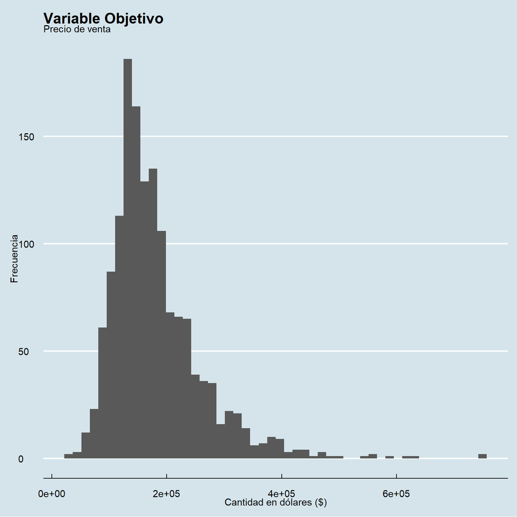

```r
ggplot(viviendas, aes(x = SalePrice)) +
    geom_histogram(bins = 50) +
    labs(title = "Variable Objetivo",
         subtitle = "Precio de venta",
          x = "Cantidad en dólares ($)",
         y = "Frecuencia") +
  theme_economist()
```

Podemos ver que es unimodal, con sesgo positivo y ciertos outliers que se pueden dislumbrar rápidamente.

## Análisis de variables numéricas

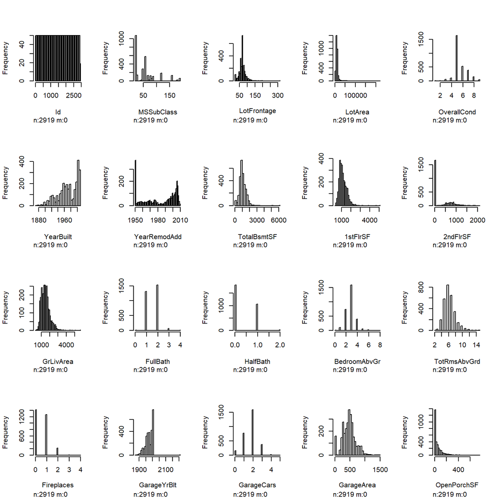

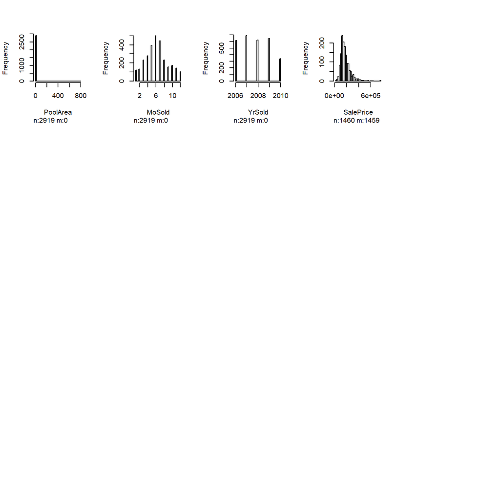

```r
hist.data.frame(viviendas |>   select(where(is.numeric)))
```

Podemos ver que tenemos variables numéricas con Outliers como la variable PoolArea, OpenPorchSF, LotArea y Lot Frontage.

Además existen variables numéricas que realmente representan una categoría como Fireplaces, GarageCars, FirePlaces, OverallCond, MoSold, BedroomAbvGr, entre otras.

## Análisis de variables categóricas

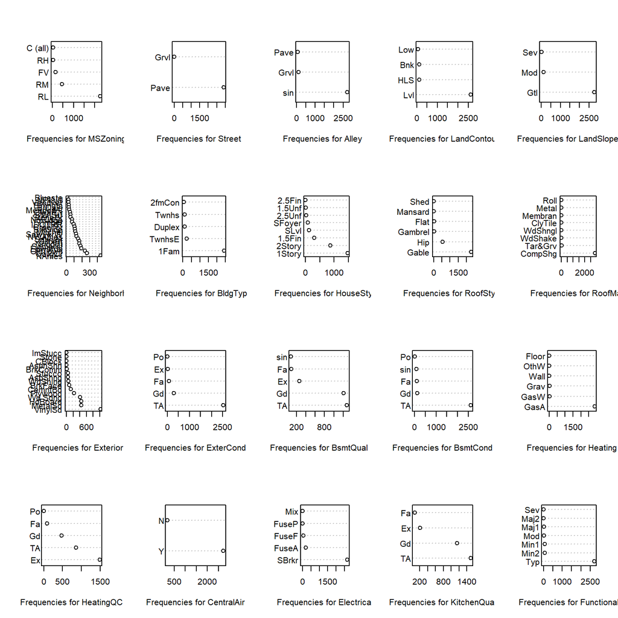

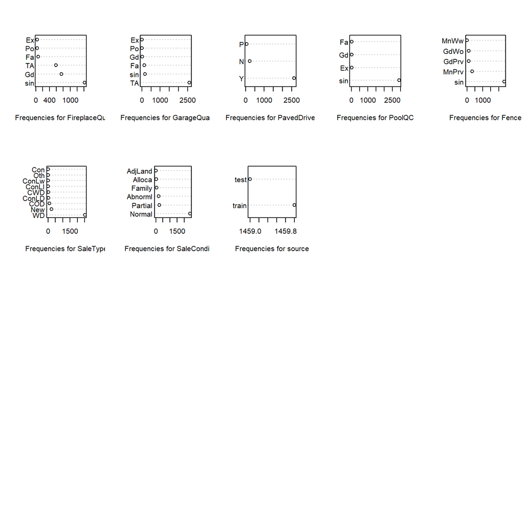

```r
hist.data.frame(viviendas |>   select(where(is.character)))
```

Podemos ver que existen variables que necesitaremos revisar su distribución ya que son prácticamente constantes como la variable Central Air, Street, LandContour, LandSlope y PoolQC, además de que algunas variables son ordinales como ExterCond, BmstQual, BsmtCond, KitchenQual, HeatinQC, FireplaceQu, GarageQual y PoolQC.

## Correlación entre variables

En vez de graficar todas las relaciones entre nuestras variables, entenderemos su correlación entre ellas y la variable objetivo, para así poder determinar qué análisis exploratorio hace sentido.

Primero separaremos nuestro dataset train

```r
viviendas_cleaned_train <- viviendas |> filter(source=="train")
```

Después realizaremos la matriz de correlación

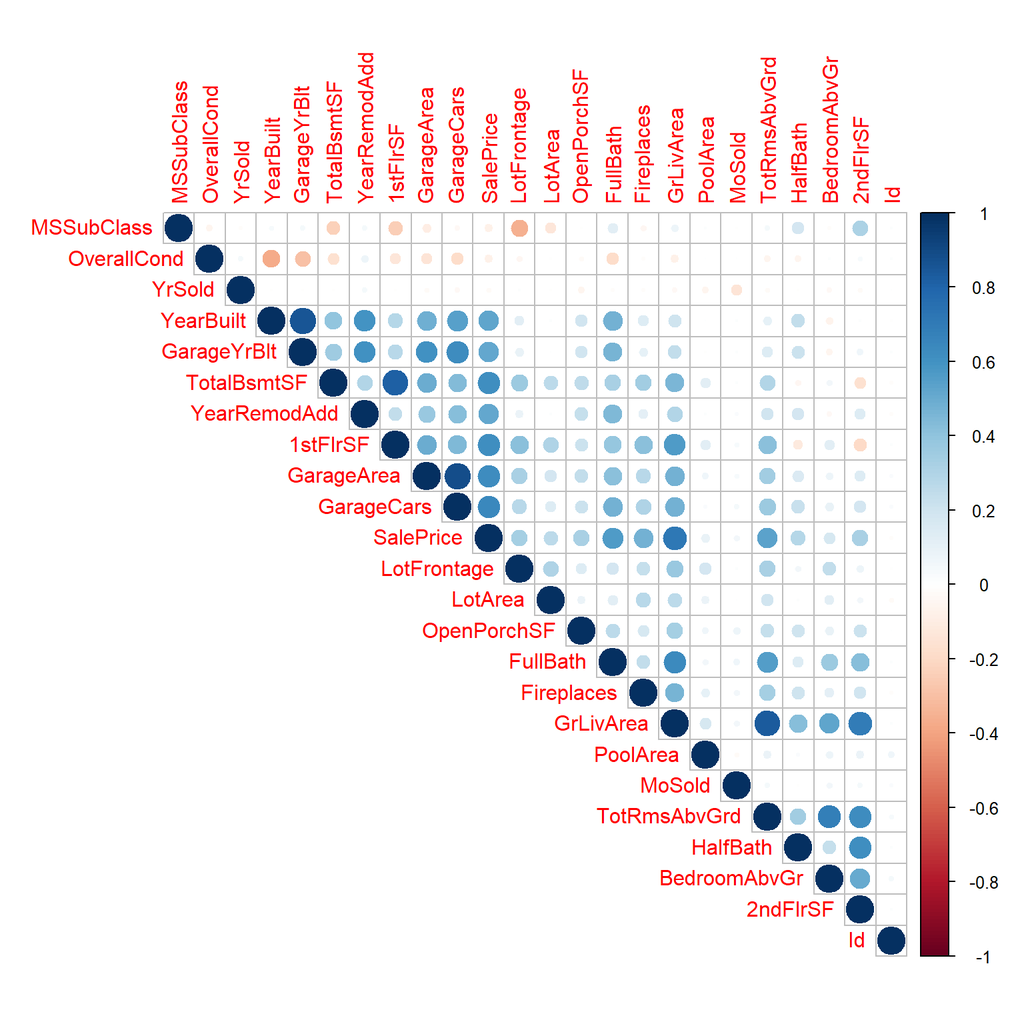

```r
cor_matrix <- viviendas_cleaned_train |> select(where(is.numeric)) |> cor() |> round(2)

cor_matrix |>
  corrplot( order = 'AOE', type = 'upper')
```

Y veamos la variables más correlacionadas:

```r
cor_matrix_rm <- viviendas_cleaned_train |> select(where(is.numeric)) |>select(-SalePrice) |>  cor() |> round(2)

cor_matrix_rm[upper.tri(cor_matrix_rm)] <- 0
diag(cor_matrix_rm) <- 0
which((!apply(cor_matrix_rm, 1,function(x) any(x > 0.7)))==FALSE)
```

```
    1stFlrSF TotRmsAbvGrd  GarageYrBlt   GarageArea
           9           15           17           19
```

Ahora extraigamos por orden descendiente las correlaciones entre nuestras variables y `SalePrice`:

```r
as.data.frame(cor_matrix)  |> select(SalePrice) |> arrange(desc(SalePrice))
```

```
             SalePrice
SalePrice         1.00
GrLivArea         0.71
GarageCars        0.64
GarageArea        0.62
TotalBsmtSF       0.61
1stFlrSF          0.61
FullBath          0.56
TotRmsAbvGrd      0.53
YearBuilt         0.52
YearRemodAdd      0.51
GarageYrBlt       0.51
Fireplaces        0.47
LotFrontage       0.33
2ndFlrSF          0.32
OpenPorchSF       0.32
HalfBath          0.28
LotArea           0.26
BedroomAbvGr      0.17
PoolArea          0.09
MoSold            0.05
Id               -0.02
YrSold           -0.03
MSSubClass       -0.08
OverallCond      -0.08
```

Podemos ver con claridad que las variables que quitaremos en la receta es 1stFlrSF, TotRmsAbvGrd y GarageYrBlt, ya que existen variables similares a ellas con mayor correlación con la variable objetivo.

Con base a los resultados anteriores nos podemos preguntar lo siguiente:

- **1. ¿Qué relación tiene el número de vehículos con el costo de la propiedad?**
- **2. ¿Las casas con áreas verdes más grandes tienden a ser más costosas?**
- **3. ¿Existe una relación directa entre el precio y la Zona?**
- **4. ¿Las casas con mejores cocinas tienden a ser más costosas?**

### ¿Qué relación tiene el número de vehículos con el costo de la propiedad?

Antes de graficar podemos observar que GarageCars es un factor y por lo tanto es necesario especificarlo en ggplot.

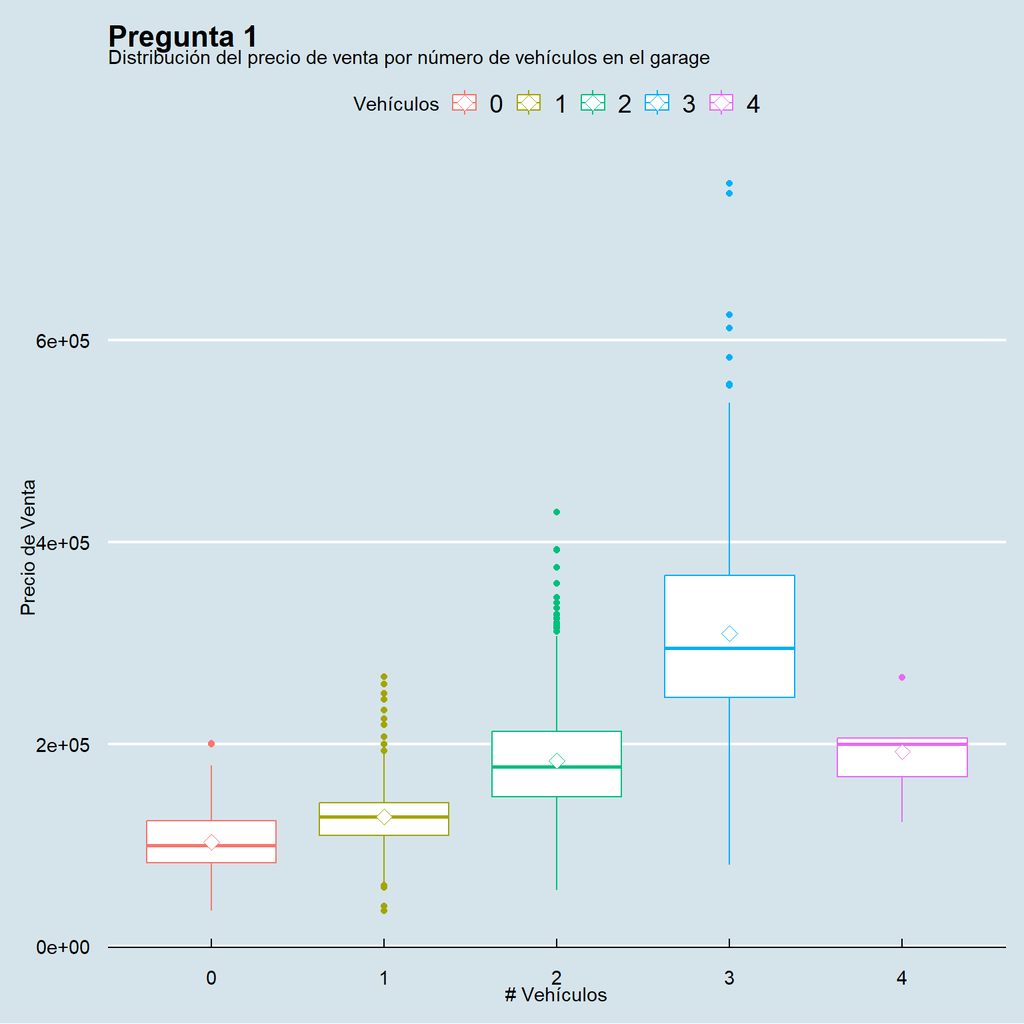

```r
ggplot(viviendas_cleaned_train, aes(x = factor(GarageCars), y = SalePrice, color=factor(GarageCars))) +
  geom_boxplot() +
  stat_summary(fun.y = "mean", geom = "point", shape = 23, size = 3, fill = "white") +
   labs(title = "Pregunta 1",
       subtitle = "Distribución del precio de venta por número de vehículos en el garage",
       x = "# Vehículos", y = "Precio de Venta", color= "Vehículos") +
  theme_economist()
```

Podemos ver que existe una relación del número de vehículos con el precio de venta, sin embargo, está no se respeta cuando se llega al número de 4 autos.

### ¿Las casas con áreas verdes más grandes tienden a ser más costosas?

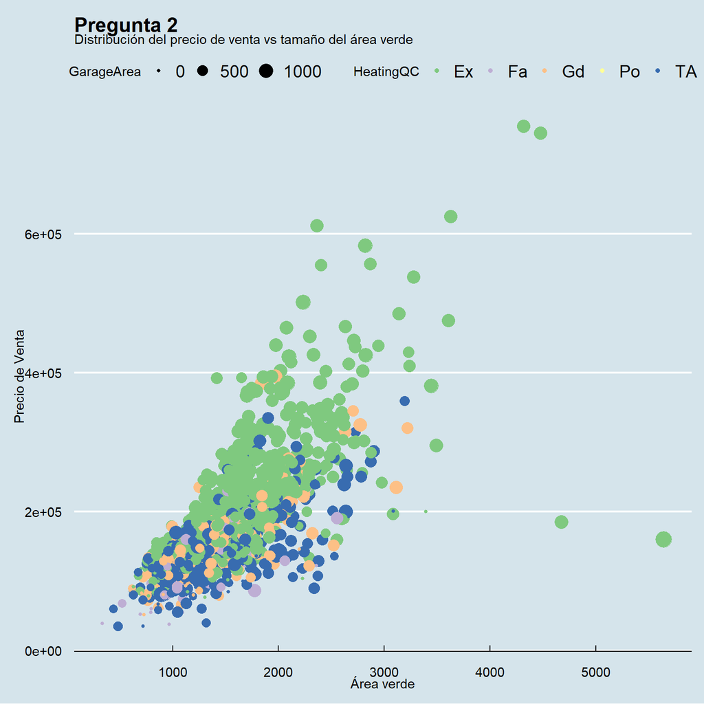

```r
ggplot(viviendas_cleaned_train, aes(x =GrLivArea , y = SalePrice, size=GarageArea, color=HeatingQC)) +
  geom_point() +
  scale_color_brewer(palette="Accent")+
   labs(title = "Pregunta 2",
       subtitle = "Distribución del precio de venta vs tamaño del área verde",
       x = "Área verde", y = "Precio de Venta") +
  theme_economist()
```

Podemos ver que sí existe una relación directa entre el precio de venta y el área verde de la casa, además vemos que la calidad de la calefacción también es una cualidad de las casas más costosas y el amplio tamaño del Garage.

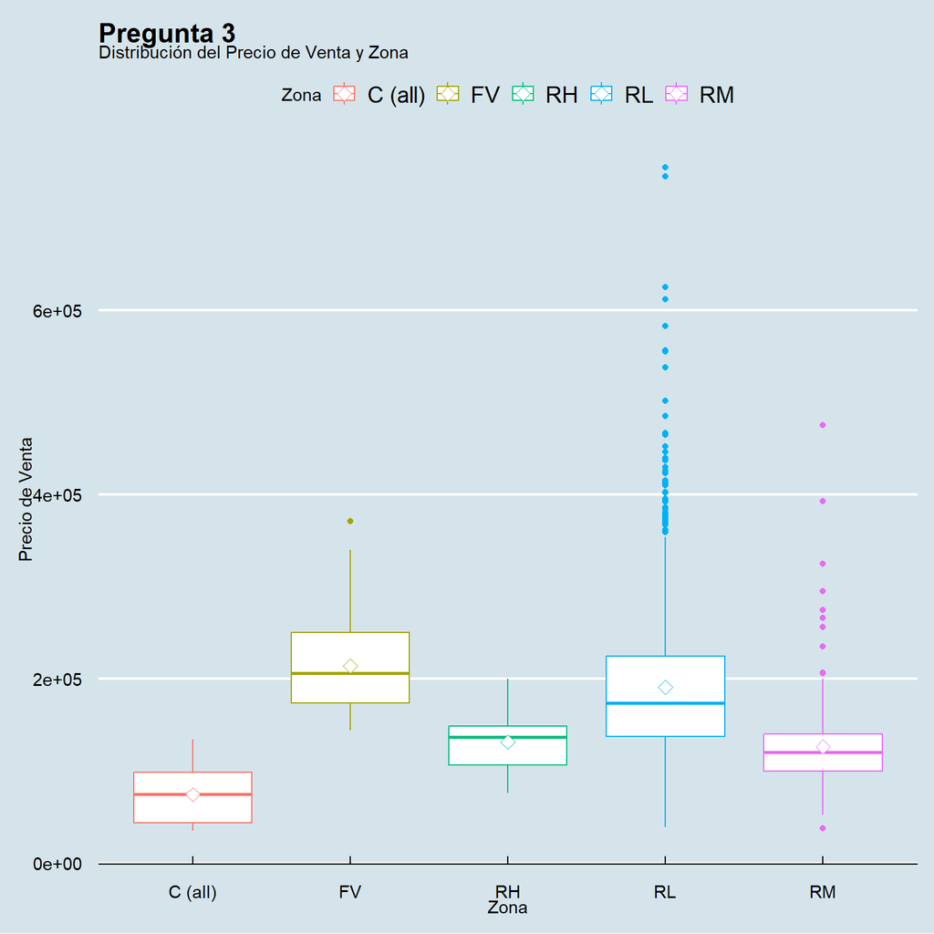

```r
ggplot(viviendas_cleaned_train, aes(x = MSZoning, y = SalePrice, color=MSZoning)) +
  geom_boxplot() +
  stat_summary(fun.y = "mean", geom = "point", shape = 23, size = 3, fill = "white") +
   labs(title = "Pregunta 3",
       subtitle = "Distribución del Precio de Venta y Zona",
       x = "Zona", y = "Precio de Venta", color= "Zona") +
  theme_economist()
```

### ¿Las casas con mejores cocinas tienden a ser más costosas?

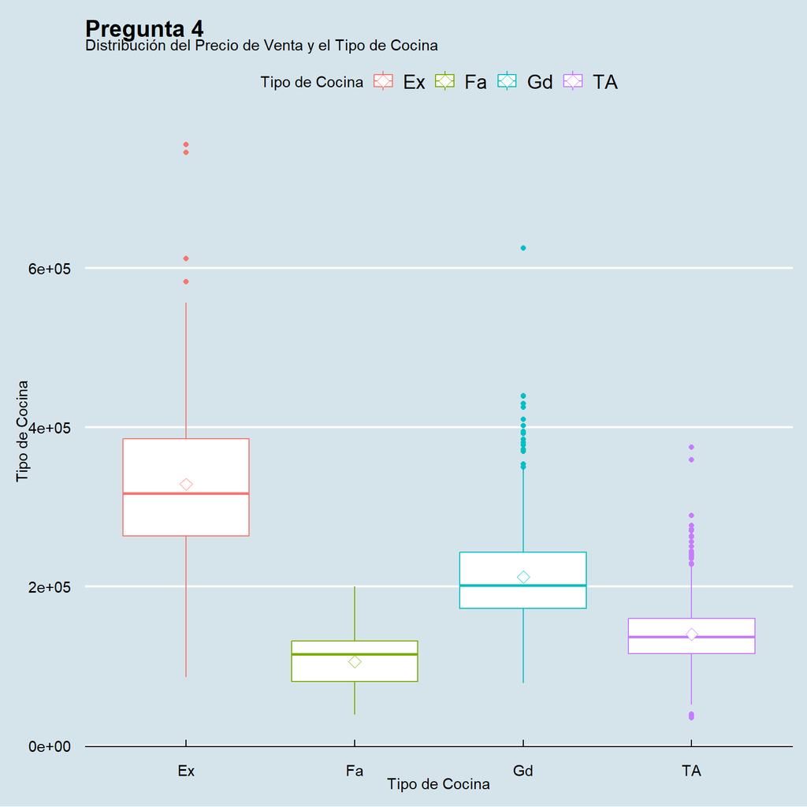

```r
ggplot(viviendas_cleaned_train, aes(x = KitchenQual, y = SalePrice, color=KitchenQual)) +
  geom_boxplot() +
  stat_summary(fun.y = "mean", geom = "point", shape = 23, size = 3, fill = "white") +
   labs(title = "Pregunta 4",
       subtitle = "Distribución del Precio de Venta y el Tipo de Cocina",
       x = "Tipo de Cocina", y = "Tipo de Cocina", color= "Tipo de Cocina") +
  theme_economist()
```

Podemos ver que sí hay una relación entre el tipo de cocina y el costo de la vivienda.

# Fase 3: Modificación (fuera de la receta)

## Factores

Una de las primeras decisiones será dotar a las variables de su **tipología correcta**: debemos decidir si las variables de tipo texto son **variables cualitativas** (factores) o simplemente id’s.

```r
viviendas |>
  select(where(is.character)) |>
  glimpse()
```

```
Rows: 2,919
Columns: 28
$ MSZoning      <chr> "RL", "RL", "RL", "RL", "RL", "RL", "RL", "RL"…
$ Street        <chr> "Pave", "Pave", "Pave", "Pave", "Pave", "Pave"…
$ Alley         <chr> "sin", "sin", "sin", "sin", "sin", "sin", "sin…
$ LandContour   <chr> "Lvl", "Lvl", "Lvl", "Lvl", "Lvl", "Lvl", "Lvl…
$ LandSlope     <chr> "Gtl", "Gtl", "Gtl", "Gtl", "Gtl", "Gtl", "Gtl…
$ Neighborhood  <chr> "CollgCr", "Veenker", "CollgCr", "Crawfor", "N…
$ BldgType      <chr> "1Fam", "1Fam", "1Fam", "1Fam", "1Fam", "1Fam"…
$ HouseStyle    <chr> "2Story", "1Story", "2Story", "2Story", "2Stor…
$ RoofStyle     <chr> "Gable", "Gable", "Gable", "Gable", "Gable", "…
$ RoofMatl      <chr> "CompShg", "CompShg", "CompShg", "CompShg", "C…
$ Exterior1st   <chr> "VinylSd", "MetalSd", "VinylSd", "Wd Sdng", "V…
$ ExterCond     <chr> "TA", "TA", "TA", "TA", "TA", "TA", "TA", "TA"…
$ BsmtQual      <chr> "Gd", "Gd", "Gd", "TA", "Gd", "Gd", "Ex", "Gd"…
$ BsmtCond      <chr> "TA", "TA", "TA", "Gd", "TA", "TA", "TA", "TA"…
$ Heating       <chr> "GasA", "GasA", "GasA", "GasA", "GasA", "GasA"…
$ HeatingQC     <chr> "Ex", "Ex", "Ex", "Gd", "Ex", "Ex", "Ex", "Ex"…
$ CentralAir    <chr> "Y", "Y", "Y", "Y", "Y", "Y", "Y", "Y", "Y", "…
$ Electrical    <chr> "SBrkr", "SBrkr", "SBrkr", "SBrkr", "SBrkr", "…
$ KitchenQual   <chr> "Gd", "TA", "Gd", "Gd", "Gd", "TA", "Gd", "TA"…
$ Functional    <chr> "Typ", "Typ", "Typ", "Typ", "Typ", "Typ", "Typ…
$ FireplaceQu   <chr> "sin", "TA", "TA", "Gd", "TA", "sin", "Gd", "T…
$ GarageQual    <chr> "TA", "TA", "TA", "TA", "TA", "TA", "TA", "TA"…
$ PavedDrive    <chr> "Y", "Y", "Y", "Y", "Y", "Y", "Y", "Y", "Y", "…
$ PoolQC        <chr> "sin", "sin", "sin", "sin", "sin", "sin", "sin…
$ Fence         <chr> "sin", "sin", "sin", "sin", "sin", "MnPrv", "s…
$ SaleType      <chr> "WD", "WD", "WD", "WD", "WD", "WD", "WD", "WD"…
$ SaleCondition <chr> "Normal", "Normal", "Normal", "Abnorml", "Norm…
$ source        <chr> "train", "train", "train", "train", "train", "…
```

Todas las variables de tipo texto representan **categorías de una cualitativa** así que las convertimos todas ellas a factor (modificación estructural –> fuera de la receta)

```r
viviendas <-
  viviendas |>
  mutate(across(where(is.character), as_factor))
```

Y además crearemos una nueva variable que representa el número de baños totales:

```r
viviendas <-
  viviendas |>
  mutate( Baths = (FullBath*2  + HalfBath))
```

Y añadiremos como factor las variables Baths, Fireplaces, GarageCars, Fireplaces, OverallCond, MoSold y BedroomAbvGr.

```r
viviendas <-
  viviendas |>
  mutate(across(c(Baths,Fireplaces,GarageCars,Fireplaces,OverallCond,MoSold,BedroomAbvGr), as_factor))
```

Ahora veamos todos los factores que están en la tabla.

```r
viviendas |> select(where(is.factor))
```

```
# A tibble: 2,919 × 34
   MSZoning Street Alley LandContour LandSlope Neigh…¹ BldgT…² House…³
   <fct>    <fct>  <fct> <fct>       <fct>     <fct>   <fct>   <fct>
 1 RL       Pave   sin   Lvl         Gtl       CollgCr 1Fam    2Story
 2 RL       Pave   sin   Lvl         Gtl       Veenker 1Fam    1Story
 3 RL       Pave   sin   Lvl         Gtl       CollgCr 1Fam    2Story
 4 RL       Pave   sin   Lvl         Gtl       Crawfor 1Fam    2Story
 5 RL       Pave   sin   Lvl         Gtl       NoRidge 1Fam    2Story
 6 RL       Pave   sin   Lvl         Gtl       Mitchel 1Fam    1.5Fin
 7 RL       Pave   sin   Lvl         Gtl       Somerst 1Fam    1Story
 8 RL       Pave   sin   Lvl         Gtl       NWAmes  1Fam    2Story
 9 RM       Pave   sin   Lvl         Gtl       OldTown 1Fam    1.5Fin
10 RL       Pave   sin   Lvl         Gtl       BrkSide 2fmCon  1.5Unf
# … with 2,909 more rows, 26 more variables: OverallCond <fct>,
#   RoofStyle <fct>, RoofMatl <fct>, Exterior1st <fct>,
#   ExterCond <fct>, BsmtQual <fct>, BsmtCond <fct>, Heating <fct>,
#   HeatingQC <fct>, CentralAir <fct>, Electrical <fct>,
#   BedroomAbvGr <fct>, KitchenQual <fct>, Functional <fct>,
#   Fireplaces <fct>, FireplaceQu <fct>, GarageCars <fct>,
#   GarageQual <fct>, PavedDrive <fct>, PoolQC <fct>, Fence <fct>, …
```

### Ordinales

Podemos ver que de nuestros factores, existen algunos con características ordinales.

Transformaremos los factores PoolQC, GarageQual, FireplaceQu, KitchenQual, HeatingQC, BsmtCond, BsmtQual y ExterCond

Primero veamos su distribución:

```r
# Variable PoolQC
viviendas |>
  count(PoolQC) |>
  mutate(porc = 100*n/sum(n))
```

```
# A tibble: 4 × 3
  PoolQC     n    porc
  <fct>  <int>   <dbl>
1 sin     2909 99.7
2 Ex         4  0.137
3 Fa         2  0.0685
4 Gd         4  0.137
```

```r
# Variable GarageQual
viviendas |>
  count(GarageQual) |>
  mutate(porc = 100*n/sum(n))
```

```
# A tibble: 6 × 3
  GarageQual     n   porc
  <fct>      <int>  <dbl>
1 TA          2604 89.2
2 Fa           124  4.25
3 Gd            24  0.822
4 sin          159  5.45
5 Ex             3  0.103
6 Po             5  0.171
```

```r
# Variable FireplaceQu
viviendas |>
  count(FireplaceQu) |>
  mutate(porc = 100*n/sum(n))
```

```
# A tibble: 6 × 3
  FireplaceQu     n  porc
  <fct>       <int> <dbl>
1 sin          1420 48.6
2 TA            592 20.3
3 Gd            744 25.5
4 Fa             74  2.54
5 Ex             43  1.47
6 Po             46  1.58
```

```r
# Variable KitchenQual
viviendas |>
  count(KitchenQual) |>
  mutate(porc = 100*n/sum(n))
```

```
# A tibble: 4 × 3
  KitchenQual     n  porc
  <fct>       <int> <dbl>
1 Gd           1151 39.4
2 TA           1493 51.1
3 Ex            205  7.02
4 Fa             70  2.40
```

```r
# Variable HeatingQC
viviendas |>
  count(HeatingQC) |>
  mutate(porc = 100*n/sum(n))
```

```
# A tibble: 5 × 3
  HeatingQC     n   porc
  <fct>     <int>  <dbl>
1 Ex         1493 51.1
2 Gd          474 16.2
3 TA          857 29.4
4 Fa           92  3.15
5 Po            3  0.103
```

```r
# Variable BsmtCond
viviendas |>
  count(BsmtCond) |>
  mutate(porc = 100*n/sum(n))
```

```
# A tibble: 5 × 3
  BsmtCond     n   porc
  <fct>    <int>  <dbl>
1 TA        2606 89.3
2 Gd         122  4.18
3 sin         82  2.81
4 Fa         104  3.56
5 Po           5  0.171
```

```r
# Variable BsmtQual
viviendas |>
  count(BsmtQual) |>
  mutate(porc = 100*n/sum(n))
```

```
# A tibble: 5 × 3
  BsmtQual     n  porc
  <fct>    <int> <dbl>
1 Gd        1209 41.4
2 TA        1283 44.0
3 Ex         258  8.84
4 sin         81  2.77
5 Fa          88  3.01
```

```r
# Variable ExterCond
viviendas |>
  count(ExterCond) |>
  mutate(porc = 100*n/sum(n))
```

```
# A tibble: 5 × 3
  ExterCond     n   porc
  <fct>     <int>  <dbl>
1 TA         2538 86.9
2 Gd          299 10.2
3 Fa           67  2.30
4 Po            3  0.103
5 Ex           12  0.411
```

Ahora les asignaremos un orden a cada categoría con base a lo que nos específica la documentación:

- `Ex Excellent`
- `Gd Good`
- `TA Average/Typical`
- `Fa Fair`
- `Po Poor`

```r
viviendas <-
  viviendas |>
  mutate(PoolQC = factor(PoolQC, levels = c("sin", "Fa", "Gd", "Ex"),ordered = TRUE),
         GarageQual = factor(GarageQual, levels = c("sin","Po", "Fa","TA", "Gd", "Ex"),ordered = TRUE),
         FireplaceQu = factor(FireplaceQu, levels = c("sin","Po", "Fa","TA", "Gd", "Ex"),ordered = TRUE),
         KitchenQual = factor(KitchenQual, levels = c("Fa","TA", "Gd", "Ex"),ordered = TRUE),
         HeatingQC = factor(HeatingQC, levels = c("Po", "Fa","TA", "Gd", "Ex"),ordered = TRUE),
         BsmtCond = factor(BsmtCond, levels = c("sin","Po", "Fa","TA", "Gd"),ordered = TRUE),
         BsmtQual = factor(BsmtCond, levels = c("sin", "Fa","TA", "Gd", "Ex"),ordered = TRUE),
         ExterCond = factor(ExterCond, levels = c("Fa","Po","TA", "Gd", "Ex"),ordered = TRUE)
         )
knitr::kable(viviendas |> select(PoolQC, GarageQual, FireplaceQu, KitchenQual, HeatingQC, BsmtCond, BsmtQual, ExterCond) |> slice_sample(n=10) )
```

| PoolQC | GarageQual | FireplaceQu | KitchenQual | HeatingQC | BsmtCond | BsmtQual | ExterCond |
| --- | --- | --- | --- | --- | --- | --- | --- |
| sin | TA | Gd | Gd | Gd | Gd | Gd | TA |
| sin | TA | Gd | Ex | Ex | Gd | Gd | Gd |
| sin | TA | Gd | Gd | Ex | TA | TA | TA |
| sin | TA | Gd | Ex | Ex | TA | TA | TA |
| sin | TA | sin | TA | TA | TA | TA | TA |
| sin | TA | TA | Gd | Ex | TA | TA | TA |
| sin | TA | sin | TA | Ex | TA | TA | TA |
| sin | TA | sin | Gd | Ex | TA | TA | TA |
| sin | Fa | sin | TA | Ex | TA | TA | Gd |
| sin | TA | TA | Gd | Ex | TA | TA | Gd |

## Separación Original

Por último separaremos nuestro dataset en Train y Test como originalmente se encontraba.

```r
viviendas_train <- viviendas |> filter(source=="train") |> select(-source)


viviendas_test <- viviendas |> filter(source=="test") |> select(-source)
```

# Fase 3: Modificación (dentro de la receta)

### Partición

#### Train - Test Partición

Partiremos nuestros datos en train 85% y test 15%, esto lo usaremos para encontrar los mejores parámetros.

```r
# Partición 10% de test
viviendas_split <- initial_split(viviendas_train, prop = 0.85)
viviendas_split
```

```
<Training/Testing/Total>
<1241/219/1460>
```

Fíjate que en `viviendas_split` solo tenemos las instrucciones. Vamos a aplicarlas

```r
# Aplicamos partición
train_data <- training(viviendas_split)
test_data <- testing(viviendas_split)
```

#### Validación por Partición

Está validación la usaremos para los modelos univariantes, modelos saturados y regresiones con selección de modelos.

```r
# Validación
validation_data <- validation_split(viviendas_train, prop = 0.7)
```

#### Validación Cruzada

```r
# Fijamos la semilla
set.seed(100)

# Declaramos el número de particiones en las que procederemos a validar.
cv_folds <-
 vfold_cv(train_data,
          v = 4,
          repeats = 1)
```

### Roles

Tras las particiones, el primer paso es **definir la receta**, indicándole el conjunto donde tenemos validación y train. Después lo que haremos será **asignar posibles roles** que nos puedan diferencias las acciones entre las variables

```r
# Receta
rec_viviendas <-
  # Fórmula y datos
  recipe(data = train_data, SalePrice ~ .)|>
  # Roles
  add_role(where(is.factor), new_role = "cuali") |>
  add_role(where(is.numeric), new_role = "cuanti") |>
  add_role(c(Id, FullBath, HalfBath, '1stFlrSF', TotRmsAbvGrd,GarageYrBlt ), new_role = "Drop_Columns")
```

###Receta Regresión Univariante

Ahora procederemos en crear la receta para la regresión univariante.

```r
# Receta
rec_reg_viviendas <-
  # Fórmula y datos
  recipe(data = train_data, SalePrice ~ GrLivArea) %>%
  step_log(GrLivArea, base = 10) %>%
  # los demás imputamos por la media
  step_mutate(GrLivArea = ifelse(abs(scores(GrLivArea, type = "z")) > 2.5, NA, GrLivArea)) %>%
  step_impute_mean(GrLivArea)
rec_reg_viviendas
```

```
Recipe

Inputs:

      role #variables
   outcome          1
 predictor          1

Operations:

Log transformation on GrLivArea
Variable mutation for ifelse(abs(scores(GrLivArea, typ...
Mean imputation for GrLivArea
```

Probaremos la receta para ver sus resultados:

```r
prepped_data <-
  rec_reg_viviendas |>  # use the recipe object
  prep() |>  # perform the recipe on training data
  juice() # extract only the preprocessed dataframe

glimpse(prepped_data)
```

```
Rows: 1,241
Columns: 2
$ GrLivArea <dbl> 3.297979, 2.885361, 3.450557, 3.318063, 3.078457, …
$ SalePrice <dbl> 205000, 133900, 582933, 234000, 79900, 302000, 246…
```

### Receta Modelo Saturado

Ahora procederemos en crear la receta para la regresión saturada.

```r
# Receta
rec_reg_saturada <-
  # Fórmula y datos
  rec_viviendas |>
  step_rm(has_role("Drop_Columns")) |>
  step_mutate(across(all_numeric_predictors(), function(x) { ifelse(abs(scores(x,type = "z")) > 2.5 & !is.na(x), NA, x) })) |>
  step_impute_bag(all_numeric_predictors()) |>
  step_impute_mode(has_role("cuali")) |>
  step_BoxCox(all_numeric_predictors()) |>
  step_other(has_role("cuali"), threshold = .1, other = "Otros")  |>
  # Normalizamos
  step_dummy(all_nominal(), -all_outcomes())  |>
  step_normalize(all_predictors()) |>
  step_zv(all_predictors()) |>
  step_corr(all_numeric_predictors(), threshold = 0.8)
rec_reg_saturada
```

```
Recipe

Inputs:

         role #variables
        cuali         33
       cuanti         19
 Drop_Columns          6
      outcome          1
    predictor         51

Operations:

Variables removed has_role("Drop_Columns")
Variable mutation for across(all_numeric_predictors(),...
Bagged tree imputation for all_numeric_predictors()
Mode imputation for has_role("cuali")
Box-Cox transformation on all_numeric_predictors()
Collapsing factor levels for has_role("cuali")
Dummy variables from all_nominal(), -all_outcomes()
Centering and scaling for all_predictors()
Zero variance filter on all_predictors()
Correlation filter on all_numeric_predictors()
```

Probaremos la receta para ver sus resultados:

```r
prepped_data <-
  rec_reg_saturada |>  # use the recipe object
  prep() |>  # perform the recipe on training data
  juice() # extract only the preprocessed dataframe

glimpse(prepped_data)
```

```
Rows: 1,241
Columns: 70
$ MSSubClass          <dbl> 0.4982563, 0.9455086, 0.4982563, 0.70041…
$ LotFrontage         <dbl> 0.7579770894, -0.3987247260, 1.606341139…
$ LotArea             <dbl> 0.79294180, -0.46089564, 0.83507491, 0.3…
$ YearBuilt           <dbl> -0.20057420, 0.03162037, 1.22576391, -1.…
$ YearRemodAdd        <dbl> 0.2615281, 0.8872487, 1.1760428, 0.93538…
$ TotalBsmtSF         <dbl> -0.65193432, -0.65193432, 1.49851686, 0.…
$ `2ndFlrSF`          <dbl> 1.0376250, -0.7866414, 1.6943608, 1.0467…
$ GrLivArea           <dbl> 0.9623951, -1.8636127, 1.9898523, 1.0981…
$ GarageArea          <dbl> 0.05602426, -0.35982934, 2.52342226, -0.…
$ OpenPorchSF         <dbl> -0.064573726, -0.683839917, 1.822713713,…
$ PoolArea            <dbl> -0.06883521, -0.06883521, -0.06883521, -…
$ YrSold              <dbl> 0.8777790, 0.8777790, 0.8777790, 0.87777…
$ SalePrice           <dbl> 205000, 133900, 582933, 234000, 79900, 3…
```

[output cut: 57 more lines]

### Receta Regresión Penalizada (Elastic Net)

Ahora procederemos en crear la receta para la regresión penalizada usando el modelo Elastic Net.

```r
# Receta
rec_reg_elastic <-
  # Fórmula y datos
  rec_viviendas |>
  step_rm(has_role("Drop_Columns")) |>
  step_mutate(across(all_numeric_predictors(), function(x) { ifelse(abs(scores(x,type = "z")) > 2.2 & !is.na(x), NA, x) })) |>
  step_impute_knn(all_numeric_predictors()) |>
  step_impute_mode(has_role("cuali")) |>
  step_BoxCox(all_numeric_predictors()) |>
  step_sqrt(SalePrice) |>
  step_other(has_role("cuali"), threshold = .2, other = "Otros")  |>
  # Normalizamos
  step_dummy(all_nominal(), -all_outcomes())  |>
  step_normalize(all_predictors()) |>
  step_zv(all_predictors()) |>
  step_corr(all_numeric_predictors(), threshold = 0.8)
rec_reg_elastic
```

```
Recipe

Inputs:

         role #variables
        cuali         33
       cuanti         19
 Drop_Columns          6
      outcome          1
    predictor         51

Operations:

Variables removed has_role("Drop_Columns")
Variable mutation for across(all_numeric_predictors(),...
K-nearest neighbor imputation for all_numeric_predictors()
Mode imputation for has_role("cuali")
Box-Cox transformation on all_numeric_predictors()
Square root transformation on SalePrice
Collapsing factor levels for has_role("cuali")
Dummy variables from all_nominal(), -all_outcomes()
Centering and scaling for all_predictors()
Zero variance filter on all_predictors()
Correlation filter on all_numeric_predictors()
```

Probaremos la receta para ver sus resultados:

```r
prepped_data <-
  rec_reg_elastic |>  # use the recipe object
  prep() |>  # perform the recipe on training data
  juice() # extract only the preprocessed dataframe

glimpse(prepped_data)
```

```
Rows: 1,241
Columns: 54
$ MSSubClass          <dbl> 0.4982563, 0.9455086, 0.4982563, 0.70041…
$ LotFrontage         <dbl> 0.7579770894, -0.3987247260, 1.606341139…
$ LotArea             <dbl> 0.79294180, -0.46089564, 0.83507491, 0.3…
$ YearBuilt           <dbl> -0.20057420, 0.03162037, 1.22576391, -1.…
$ YearRemodAdd        <dbl> 0.2615281, 0.8872487, 1.1760428, 0.93538…
$ TotalBsmtSF         <dbl> -0.65193432, -0.65193432, 1.49851686, 0.…
$ `2ndFlrSF`          <dbl> 1.0376250, -0.7866414, 1.6943608, 1.0467…
$ GrLivArea           <dbl> 0.9623951, -1.8636127, 1.9898523, 1.0981…
$ GarageArea          <dbl> 0.05602426, -0.35982934, 2.52342226, -0.…
$ OpenPorchSF         <dbl> -0.064573726, -0.683839917, 1.822713713,…
$ PoolArea            <dbl> -0.06883521, -0.06883521, -0.06883521, -…
$ YrSold              <dbl> 0.8777790, 0.8777790, 0.8777790, 0.87777…
$ SalePrice           <dbl> 452.7693, 365.9235, 763.5005, 483.7355, …
```

[output cut: 41 more lines]

# Fase 4 Modelling

## Fase 4 Regresión Univariante

### Flujo y Evaluación Regresión Univariante

Primero generamos el modelo lineal, el flujo y evaluamos el modelo con los datos de validación.

```r
# Modelo lineal
reg_lineal <- linear_reg() %>% set_mode("regression") %>% set_engine("lm")

# Flujo de Trabajo
reg_wflow_viviendas <-
  workflow() %>%
  add_model(reg_lineal) %>%
  add_recipe(rec_reg_viviendas)

# Evaluación del modelo a los datos de validación
reg_fit_viviendas <-
  reg_wflow_viviendas %>%
  fit_resamples(resamples = validation_data)

# Métricas de error
reg_fit_viviendas |> collect_metrics()
```

```
# A tibble: 2 × 6
  .metric .estimator      mean     n std_err .config
  <chr>   <chr>          <dbl> <int>   <dbl> <chr>
1 rmse    standard   63142.        1      NA Preprocessor1_Model1
2 rsq     standard       0.422     1      NA Preprocessor1_Model1
```

### Interpretación de resultados

```r
reg_fit_viviendas <-  reg_wflow_viviendas %>% fit(viviendas_train)
tidy(reg_fit_viviendas)
```

```
# A tibble: 2 × 5
  term         estimate std.error statistic   p.value
  <chr>           <dbl>     <dbl>     <dbl>     <dbl>
1 (Intercept) -1012224.    36341.     -27.9 2.99e-137
2 GrLivArea     378115.    11506.      32.9 1.04e-177
```

La predicción del precio de la vivienda es -1,012,224 dólares cuando el logaritmo de la variable GrLivArea es 0, y por cada unidad en que el logaritmo base 10 aumenta el precio de la vivienda aumenta 378115.2 dólares

### Representación de resultados

Hagamos la representación de los resultados:

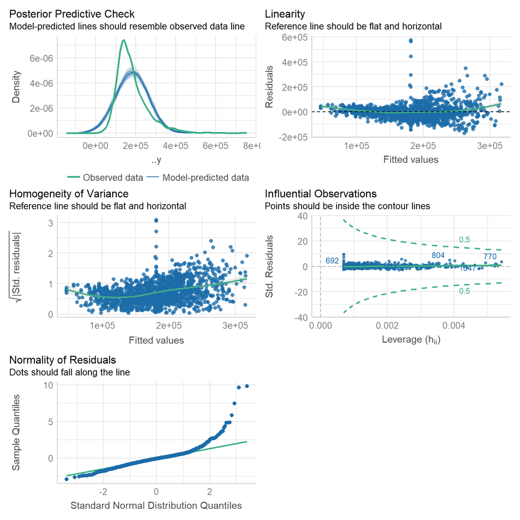

```r
check_model(reg_fit_viviendas %>% extract_fit_engine())
```

#### Intervalos de confianza de la estimación

Podemos ver los coeficientes en los que ronda el 95% de probabilidad en que los parámetros sean los adecuados, mas no la población.

```r
confint(reg_fit_viviendas %>% extract_fit_engine())
```

```
                 2.5 %    97.5 %
(Intercept) -1083511.1 -940936.9
GrLivArea     355545.1  400685.3
```

Para esto es importante citar la fuente https://www.investopedia.com/terms/c/confidenceinterval.asp

**What Is a Common Misconception About Confidence Intervals?**

The biggest misconception regarding confidence intervals is that they represent the percentage of data from a given sample that falls between the upper and lower bounds. In other words, it would be incorrect to assume that a 99% confidence interval means that 99% of the data in a random sample falls between these bounds. What it actually means is that one can be 99% certain that the range will contain the population mean.

[figure not shown]

#### Linealidad

Se espera que entre los residuos no exista tendencia significativa, sin embargo, podemos ver que nuestros residuos siguen una tendencia en forma de U, esto puede ser porque le falta información al modelo.

#### ANOVA (Analysis of Variance)

Haciendo un test anova de nuestros predictores vs los residuos, tenemos lo siguientes resultados con respecto a una relación lineal:

```r
ajuste <- reg_fit_viviendas %>% extract_fit_engine()
lm(ajuste$residuals ~ ajuste$fitted.values) %>% anova()
```

```
Analysis of Variance Table

Response: ajuste$residuals
                       Df     Sum Sq    Mean Sq F value Pr(>F)
ajuste$fitted.values    1 0.0000e+00          0       0      1
Residuals            1458 5.2898e+12 3628103502
```

Vemos que el p-valor Pr(>F) de la prueba realizada es bastante grande, por lo que no parece existir tendencia lineal entre los residuos.

Ahora lo haremos revisando la tendencia cuadrática.

```r
lm(ajuste$residuals ~ I(ajuste$fitted.values^2) + ajuste$fitted.values) %>% anova()
```

```
Analysis of Variance Table

Response: ajuste$residuals
                            Df     Sum Sq    Mean Sq F value
I(ajuste$fitted.values^2)    1 5.3864e+09 5.3864e+09  1.5331
ajuste$fitted.values         1 1.6522e+11 1.6522e+11 47.0242
Residuals                 1457 5.1192e+12 3.5135e+09
                             Pr(>F)
I(ajuste$fitted.values^2)    0.2159
ajuste$fitted.values      1.033e-11 ***
Residuals
---
Signif. codes:  0 '***' 0.001 '**' 0.01 '*' 0.05 '.' 0.1 ' ' 1
```

Podemos ver que sigue sin existir una tendencia cuadrática

#### Homecedasticidad

```r
#Revisar Homecedasticidad
check_heteroscedasticity(ajuste)
```

[output not shown]

#### Diagnosis de Regresión

Grafiquemos los residuales

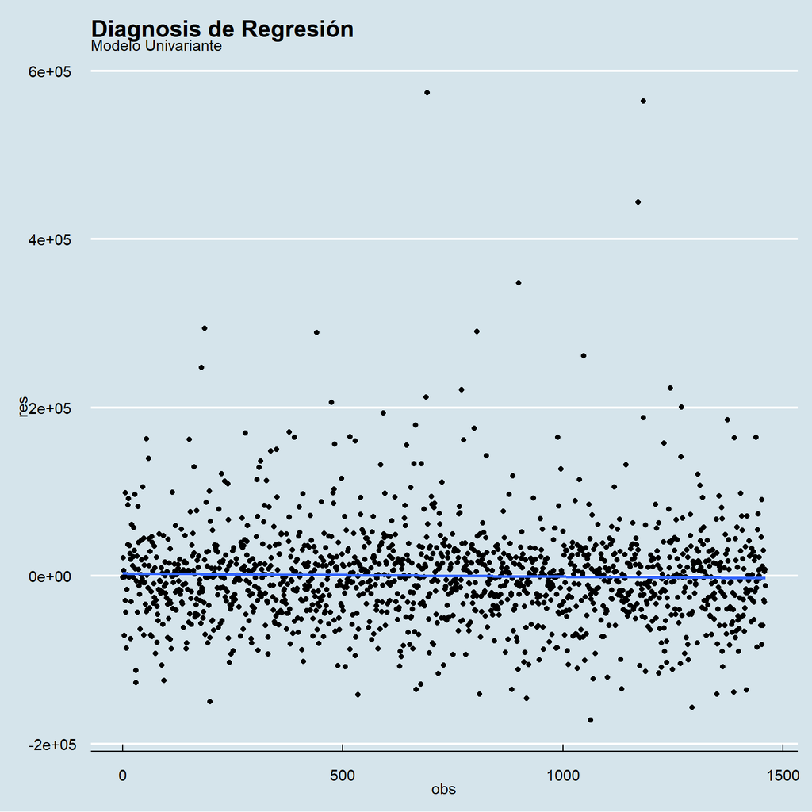

```r
ggplot(
  tibble("obs" = 1:length(ajuste$residuals),
         "res" = ajuste$residuals),
  aes(x = obs, y = res)) +
  geom_point() +
  geom_smooth(method = "lm", se = FALSE) +
  labs(title="Diagnosis de Regresión", subtitle="Modelo Univariante")+
  theme_economist()
```

Podemos ver que no existe una banda de error definida.

#### Normalidad de los residuos

Podemos ver que en ninguno de los casos supera el test de normalidad, e incluso la recta en el gráfico QQ Plot no se sigue, por lo tanto, la recomendación es transformar la objetivo tomando raíz cuadrada, logaritmo o transformaciones Box-Cox para variables positivas, o transformaciones Yeo-Johnson para variables que puedan tomar valores negativos.

```r
ols_test_normality(ajuste$residuals)
```

```
-----------------------------------------------
       Test             Statistic       pvalue
-----------------------------------------------
Shapiro-Wilk              0.8673         0.0000
Kolmogorov-Smirnov        0.1075         0.0000
Cramer-von Mises         122.818         0.0000
Anderson-Darling         28.2411         0.0000
-----------------------------------------------
```

#### Incorrelación de residuos

```r
durbinWatsonTest(ajuste)
```

```
 lag Autocorrelation D-W Statistic p-value
   1      0.01468839      1.970595   0.566
 Alternative hypothesis: rho != 0
```

No hay evidencia suficiente para rechazar la hipótesis nula, por lo tanto no podemos asegurar que se encuentran incorrelados.

#### Resumen de evaluación del modelo

```r
glance(reg_fit_viviendas)
```

```
# A tibble: 1 × 12
  r.squ…¹ adj.r…²  sigma stati…³   p.value    df  logLik    AIC    BIC
    <dbl>   <dbl>  <dbl>   <dbl>     <dbl> <dbl>   <dbl>  <dbl>  <dbl>
1   0.426   0.425 60234.   1080. 1.04e-177     1 -18139. 36285. 36301.
# … with 3 more variables: deviance <dbl>, df.residual <int>,
#   nobs <int>, and abbreviated variable names ¹r.squared,
#   ²adj.r.squared, ³statistic
```

#### Predicción

Ahora realizaremos la evaluación y predicción en Test.

```r
# Predecimos en tst
fit_viviendas <- reg_wflow_viviendas %>% last_fit(split = viviendas_split)
# Evaluamos en test
fit_viviendas %>% collect_metrics()
```

```
# A tibble: 2 × 4
  .metric .estimator .estimate .config
  <chr>   <chr>          <dbl> <chr>
1 rmse    standard   53719.    Preprocessor1_Model1
2 rsq     standard       0.435 Preprocessor1_Model1
```

Vemos que las métricas son muy similares al set de validación.

```r
# Errores en test
pred_test <-
  fit_viviendas %>%
  collect_predictions() %>%
  mutate(error = SalePrice - .pred)
pred_test
```

```
# A tibble: 219 × 6
   id                 .pred  .row SalePrice .config              error
   <chr>              <dbl> <int>     <dbl> <chr>                <dbl>
 1 train/test split 173074.     6    143000 Preprocessor1_Mod… -3.01e4
 2 train/test split 216283.     9    129900 Preprocessor1_Mod… -8.64e4
 3 train/test split  96757.    16    132000 Preprocessor1_Mod…  3.52e4
 4 train/test split 264054.    21    325300 Preprocessor1_Mod…  6.12e4
 5 train/test split 199405.    29    207500 Preprocessor1_Mod…  8.10e3
 6 train/test split 181142.    30     68500 Preprocessor1_Mod… -1.13e5
 7 train/test split 269202.    36    309000 Preprocessor1_Mod…  3.98e4
 8 train/test split 214243.    46    319900 Preprocessor1_Mod…  1.06e5
 9 train/test split 183536.    49    113000 Preprocessor1_Mod… -7.05e4
10 train/test split 115033.    50    127000 Preprocessor1_Mod…  1.20e4
# … with 209 more rows
```

Calculamos el error y graficamos la predicción con el valor real.

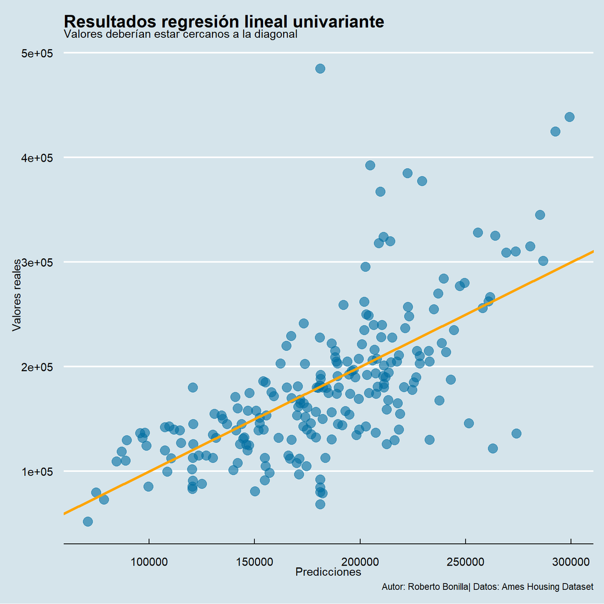

```r
# Gráficos en test
ggplot(data = pred_test,
       mapping = aes(x = .pred,
                     y = SalePrice)) +
  geom_point(color = "#006EA1",
             alpha = 0.6,
             size = 4) +
  # Diagonal
  geom_abline(intercept = 0, slope = 1,
              color = "orange", size = 1.2) +
  theme_economist() +
  labs(title = "Resultados regresión lineal univariante",
       subtitle =
         "Valores deberían estar cercanos a la diagonal",
       caption =
         "Autor: Roberto Bonilla| Datos: Ames Housing Dataset",
       x = "Predicciones",
       y = "Valores reales")
```

Podemos ver que los valores están cercanos a la diagonal cuando las casas son de precio medio y bajo, sin embargo, con las casas de precio alto la predicción tiene un error muy alto.

## Fase 4 Regresión Saturada

### Flujo y Evaluación Regresión Saturada

Primero generamos el modelo lineal, el flujo y evaluamos el modelo con los datos de validación.

```r
# Modelo lineal
reg_lineal <- linear_reg() %>% set_mode("regression") %>% set_engine("lm")

# Flujo de Trabajo
reg_wflow_saturada <-
  workflow() %>%
  add_model(reg_lineal) %>%
  add_recipe(rec_reg_saturada)

# Evaluación del modelo a los datos de validación
reg_fit_saturada <-
  reg_wflow_saturada %>%
  fit_resamples(resamples = validation_data)

# Métricas de error
reg_fit_saturada |> collect_metrics()
```

```
# A tibble: 2 × 6
  .metric .estimator      mean     n std_err .config
  <chr>   <chr>          <dbl> <int>   <dbl> <chr>
1 rmse    standard   40009.        1      NA Preprocessor1_Model1
2 rsq     standard       0.769     1      NA Preprocessor1_Model1
```

### Interpretación de resultados

```r
reg_fit_saturada <-  reg_wflow_saturada %>% fit(viviendas_train)
tidy(reg_fit_saturada)
```

```
# A tibble: 71 × 5
   term         estimate std.error statistic  p.value
   <chr>           <dbl>     <dbl>     <dbl>    <dbl>
 1 (Intercept)   180921.      906.    200.   0
 2 MSSubClass      3356.     2856.      1.18 2.40e- 1
 3 LotFrontage    -3564.     1286.     -2.77 5.64e- 3
 4 LotArea         7660.     1515.      5.06 4.81e- 7
 5 YearBuilt      19035.     2225.      8.56 3.03e-17
 6 YearRemodAdd    7220.     1498.      4.82 1.59e- 6
 7 TotalBsmtSF    10821.     1708.      6.33 3.20e-10
 8 `2ndFlrSF`      8567.     3107.      2.76 5.90e- 3
 9 GrLivArea      25452.     2581.      9.86 3.17e-22
10 GarageArea      2202.     1938.      1.14 2.56e- 1
# … with 61 more rows
```

### Representación de resultados

Hagamos la representación de los resultados:

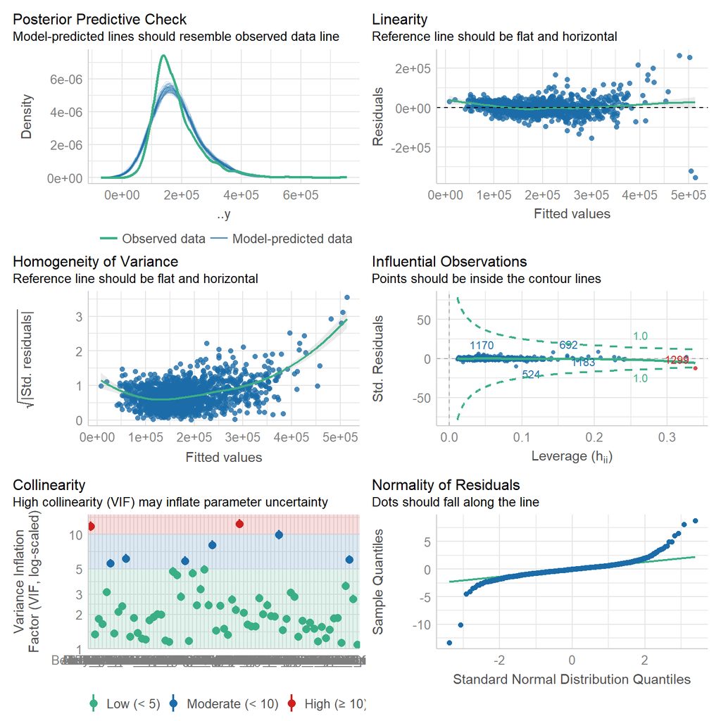

```r
check_model(reg_fit_saturada %>% extract_fit_engine())
```

Podemos ver que existe colinealidad en nuestras variables y eso puede afectar con ruido en la regresión.

#### Intervalos de confianza de la estimación

Podemos ver los coeficientes en los que ronda el 95% de probabilidad en que los parámetros sean los adecuados, mas no la población.

```r
confint(reg_fit_saturada %>% extract_fit_engine())
```

```
                          2.5 %      97.5 %
(Intercept)         179143.8471 182698.6005
MSSubClass           -2245.7179   8957.9451
LotFrontage          -6086.5159  -1042.3103
LotArea               4689.3021  10631.6787
YearBuilt            14671.0056  23398.7401
YearRemodAdd          4281.2464  10157.9930
TotalBsmtSF           7470.5019  14172.3862
`2ndFlrSF`            2472.4185  14662.0727
GrLivArea            20389.8111  30514.3646
GarageArea           -1600.7164   6003.7172
OpenPorchSF          -1736.0279   2296.9452
PoolArea             -2246.5967   1594.5807
YrSold               -1525.6250   2183.6690
MSZoning_RM          -2246.9964   2573.2456
MSZoning_Otros       -1418.7378   2889.3991
Street_Otros         -5007.2865  -1220.1512
Alley_Otros          -2441.8990   1680.8955
LandContour_Otros    -4130.0454    336.2472
LandSlope_Otros       2258.0859   6734.2638
Neighborhood_NAmes   -3581.2691   2679.7891
Neighborhood_Otros   -1469.6720   4556.2237
BldgType_Otros      -10972.8042  -2143.9069
HouseStyle_X1Story    1594.8519  14122.8152
HouseStyle_X1.5Fin   -1578.8595   3698.0327
HouseStyle_Otros       352.0312   6208.2230
OverallCond_X6         247.6037   4580.9056
OverallCond_X7        1359.7205   5993.4791
OverallCond_Otros    -2074.3549   2642.3544
RoofStyle_Hip         1178.6782   5155.7672
RoofStyle_Otros      -2361.5355   1952.0416
RoofMatl_Otros       -1435.0293   3017.5447
Exterior1st_MetalSd  -1257.1604   3643.8737
Exterior1st_Wd.Sdng   -491.9823   4528.0119
Exterior1st_HdBoard  -1403.6325   3335.9153
Exterior1st_Otros     -546.0856   4500.8917
ExterCond_Gd          -490.5319   3453.1270
ExterCond_Otros      -2185.0387   1723.6422
BsmtQual_Otros       -3360.7347    661.1314
Heating_Otros        -2409.1621   1872.8826
```

[output cut: 17 more lines]

```
GarageCars_X3        12880.8813  20784.7676
GarageCars_Otros     -4055.7793   1469.6176
GarageQual_Otros     -2354.3761   3182.0623
PavedDrive_Otros     -3176.7184   1186.8958
Fence_MnPrv          -1539.8824   2332.9224
Fence_Otros          -1924.1279   1900.2203
MoSold_X6            -2358.3101   2605.6800
MoSold_X7            -1456.9999   3471.5976
MoSold_Otros         -4197.5183   1336.0036
SaleType_Otros         684.1040   5546.0840
SaleCondition_Otros  -5637.1276   -804.6311
Baths_X3             -2067.3487   2515.3665
Baths_X4             -5128.4341   1164.2589
Baths_X5             -6553.9306   1846.3135
Baths_Otros           2912.7414   7735.9193
```

#### Linealidad

Se espera que entre los residuos no exista tendencia significativa, y en el gráfico podemos observar que el patrón que se sigue es el esperado donde los residuos no se alejan con alguna tendencia de la predicción.

#### ANOVA (Analysis of Variance)

Haciendo un test anova de nuestros predictores vs los residuos, tenemos lo siguientes resultados con respecto a una relación lineal:

```r
ajuste <- reg_fit_saturada %>% extract_fit_engine()
lm(ajuste$residuals ~ ajuste$fitted.values) %>% anova()
```

```
Analysis of Variance Table

Response: ajuste$residuals
                       Df    Sum Sq    Mean Sq F value Pr(>F)
ajuste$fitted.values    1 0.000e+00          0       0      1
Residuals            1458 1.666e+12 1142657964
```

Vemos que el p-valor Pr(>F) de la prueba realizada es bastante grande, por lo que no parece existir tendencia lineal entre los residuos.

Ahora lo haremos revisando la tendencia cuadrática.

```r
lm(ajuste$residuals ~ I(ajuste$fitted.values^2) + ajuste$fitted.values) %>% anova()
```

```
Analysis of Variance Table

Response: ajuste$residuals
                            Df     Sum Sq    Mean Sq F value   Pr(>F)
I(ajuste$fitted.values^2)    1 4.4295e+09 4.4295e+09  4.0433  0.04453
ajuste$fitted.values         1 6.5407e+10 6.5407e+10 59.7042 2.04e-14
Residuals                 1457 1.5962e+12 1.0955e+09

I(ajuste$fitted.values^2) *
ajuste$fitted.values      ***
Residuals
---
Signif. codes:  0 '***' 0.001 '**' 0.01 '*' 0.05 '.' 0.1 ' ' 1
```

#### Homecedasticidad

```r
#Revisar Homecedasticidad
check_heteroscedasticity(ajuste)
```

[output not shown]

#### Diagnosis de Regresión

Grafiquemos los residuales

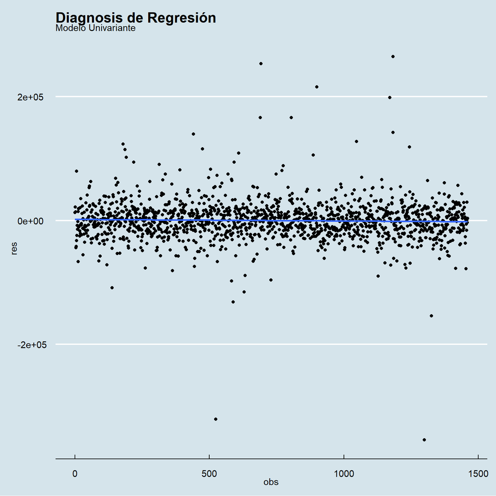

```r
ggplot(
  tibble("obs" = 1:length(ajuste$residuals),
         "res" = ajuste$residuals),
  aes(x = obs, y = res)) +
  geom_point() +
  geom_smooth(method = "lm", se = FALSE) +
  labs(title="Diagnosis de Regresión", subtitle="Modelo Univariante")+
  theme_economist()
```

Podemos ver que no existe una banda de error definida, sin embargo los residuos parecen seguir una recta en su tendencia (lo cual es adecuado).

#### Normalidad de los residuos

Podemos ver que en ninguno de los casos supera el test de normalidad, e incluso la recta en el gráfico QQ Plot no se sigue, por lo tanto, la recomendación es transformar la objetivo tomando raíz cuadrada, logaritmo o transformaciones Box-Cox para variables positivas, o transformaciones Yeo-Johnson para variables que puedan tomar valores negativos.

```r
ols_test_normality(ajuste$residuals)
```

```
-----------------------------------------------
       Test             Statistic       pvalue
-----------------------------------------------
Shapiro-Wilk              0.8358         0.0000
Kolmogorov-Smirnov        0.1004         0.0000
Cramer-von Mises         121.8009        0.0000
Anderson-Darling         31.9663         0.0000
-----------------------------------------------
```

#### Incorrelación de residuos

```r
durbinWatsonTest(ajuste)
```

```
 lag Autocorrelation D-W Statistic p-value
   1      0.02463697      1.950624   0.318
 Alternative hypothesis: rho != 0
```

No hay evidencia suficiente para rechazar la hipótesis nula, por lo tanto no podemos asegurar que se encuentran incorrelados.

#### Resumen de evaluación del modelo

```r
glance(reg_fit_saturada)
```

```
# A tibble: 1 × 12
  r.squared adj.r…¹  sigma stati…² p.value    df  logLik    AIC    BIC
      <dbl>   <dbl>  <dbl>   <dbl>   <dbl> <dbl>   <dbl>  <dbl>  <dbl>
1     0.819   0.810 34620.    91.2       0    69 -17296. 34734. 35109.
# … with 3 more variables: deviance <dbl>, df.residual <int>,
#   nobs <int>, and abbreviated variable names ¹adj.r.squared,
#   ²statistic
```

#### Predicción

Ahora realizaremos la evaluación y predicción en Test.

```r
# Predecimos en tst
fit_saturada <- reg_wflow_saturada %>% last_fit(split = viviendas_split)
# Evaluamos en test
fit_saturada %>% collect_metrics()
```

```
# A tibble: 2 × 4
  .metric .estimator .estimate .config
  <chr>   <chr>          <dbl> <chr>
1 rmse    standard   25962.    Preprocessor1_Model1
2 rsq     standard       0.868 Preprocessor1_Model1
```

```r
# Errores en test
pred_test <-
  fit_saturada %>%
  collect_predictions() %>%
  mutate(error = SalePrice - .pred)
pred_test
```

```
# A tibble: 219 × 6
   id                 .pred  .row SalePrice .config              error
   <chr>              <dbl> <int>     <dbl> <chr>                <dbl>
 1 train/test split 176131.     6    143000 Preprocessor1_Mod… -33131.
 2 train/test split 138919.     9    129900 Preprocessor1_Mod…  -9019.
 3 train/test split 110261.    16    132000 Preprocessor1_Mod…  21739.
 4 train/test split 346913.    21    325300 Preprocessor1_Mod… -21613.
 5 train/test split 222527.    29    207500 Preprocessor1_Mod… -15027.
 6 train/test split  63390.    30     68500 Preprocessor1_Mod…   5110.
 7 train/test split 346569.    36    309000 Preprocessor1_Mod… -37569.
 8 train/test split 276249.    46    319900 Preprocessor1_Mod…  43651.
 9 train/test split 104384.    49    113000 Preprocessor1_Mod…   8616.
10 train/test split 123102.    50    127000 Preprocessor1_Mod…   3898.
# … with 209 more rows
```

Calculamos el error y graficamos la predicción con el valor real.

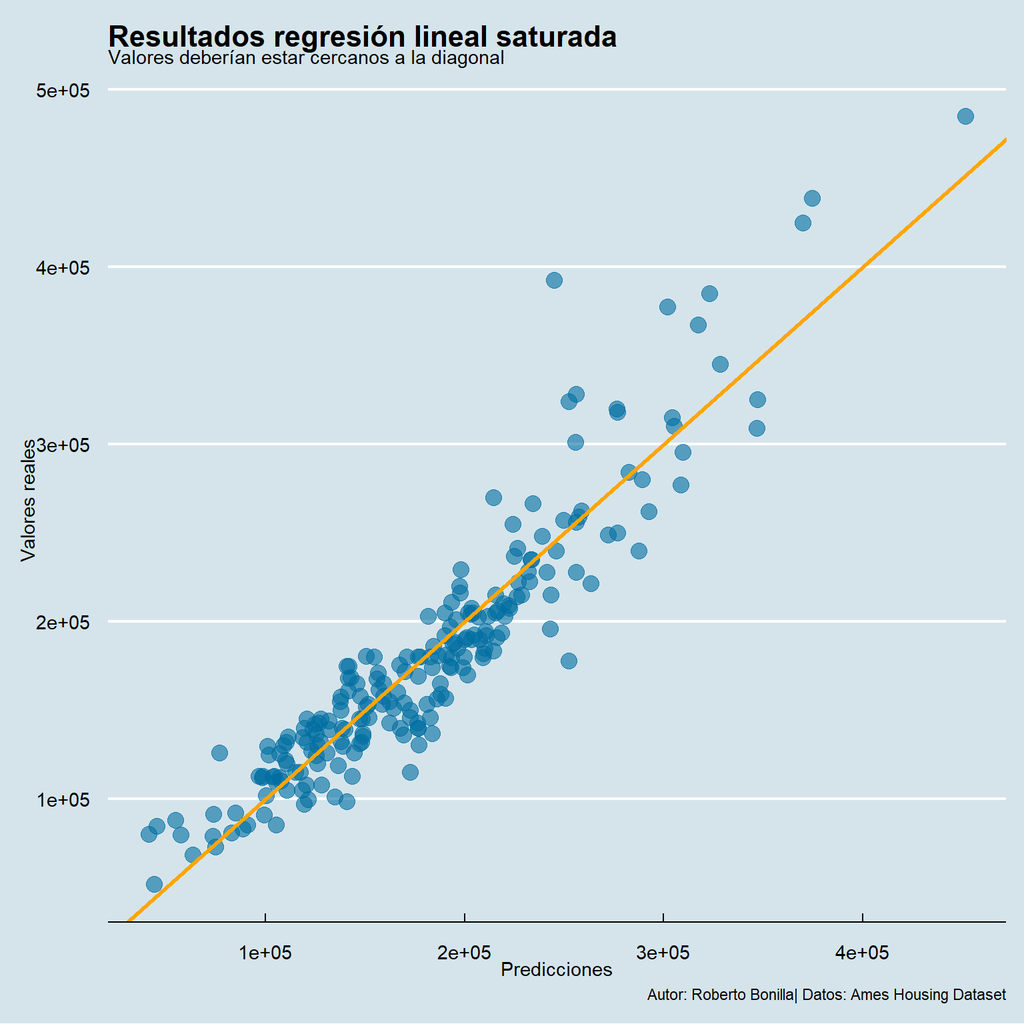

```r
# Gráficos en test
ggplot(data = pred_test,
       mapping = aes(x = .pred,
                     y = SalePrice)) +
  geom_point(color = "#006EA1",
             alpha = 0.6,
             size = 4) +
  # Diagonal
  geom_abline(intercept = 0, slope = 1,
              color = "orange", size = 1.2) +
  theme_economist() +
  labs(title = "Resultados regresión lineal saturada",
       subtitle =
         "Valores deberían estar cercanos a la diagonal",
       caption =
         "Autor: Roberto Bonilla| Datos: Ames Housing Dataset",
       x = "Predicciones",
       y = "Valores reales")
```

Podemos ver que los valores están cercanos a la diagonal con mucha más frecuencia, sin embargo, los residuales siguen un poco separados de la recta.

## Fase 4 Regresión Penalizada (Elastic Net)

### Definición del Modelo

Primero generamos el modelo definido por el motor glmnet donde mixture será el parámetro α y penalty el parámetro λ, el flujo y evaluamos el modelo con los datos de validación.

```r
# Modelo lineal
elastic_net <-
  linear_reg(mixture = tune("alpha"), penalty = tune("lambda")) %>%
  set_mode("regression") %>% set_engine("glmnet")
```

### Grid de parámetros

Y vamos a generar un grid de parámetros (200 regresiones) usando penalty() (fíjate que está en escala logarítmica, es decir, que -2 es una penalización de 0.01 y 2 de 100)

```r
grid_elastic_net <-
  expand_grid("alpha" = seq(0, 1, l = 5),
              "lambda" = grid_regular(penalty(range = c(-4, 1)), levels = 40) %>%
                pull(penalty))
```

### Hiperparametrización

```r
wflow_elastic <-
  workflow() %>% add_recipe(rec_reg_elastic) %>% add_model(elastic_net)

mod_elastic <- wflow_elastic %>%
  tune_grid(resamples = cv_folds, grid = grid_elastic_net,
            control = control_grid(verbose = TRUE))
```

### Selección del mejor modelo

```r
# Muestra del mejor modelo en R cuadrada
mod_elastic %>% show_best("rsq")
```

```
# A tibble: 5 × 8
  lambda alpha .metric .estimator  mean     n std_err .config
   <dbl> <dbl> <chr>   <chr>      <dbl> <int>   <dbl> <chr>
1   1.70  0.75 rsq     standard   0.809     4  0.0343 Preprocessor1_M…
2   1.27  1    rsq     standard   0.809     4  0.0343 Preprocessor1_M…
3   2.29  0.5  rsq     standard   0.809     4  0.0342 Preprocessor1_M…
4   5.54  0.25 rsq     standard   0.808     4  0.0344 Preprocessor1_M…
5   4.12  0.25 rsq     standard   0.808     4  0.0341 Preprocessor1_M…
```

```r
# Muestra del mejor modelo en RMSE
mod_elastic %>% show_best("rmse")
```

```
# A tibble: 5 × 8
  lambda alpha .metric .estimator  mean     n std_err .config
   <dbl> <dbl> <chr>   <chr>      <dbl> <int>   <dbl> <chr>
1  1.27   1    rmse    standard    38.2     4    3.36 Preprocessor1_M…
2  1.70   0.75 rmse    standard    38.2     4    3.36 Preprocessor1_M…
3  2.29   0.5  rmse    standard    38.3     4    3.35 Preprocessor1_M…
4  0.943  1    rmse    standard    38.3     4    3.35 Preprocessor1_M…
5  1.27   0.75 rmse    standard    38.3     4    3.34 Preprocessor1_M…
```

```r
# Selección del mejor modelo en R cuadrada
mod_elastic %>% select_best("rsq")
```

```
# A tibble: 1 × 3
  lambda alpha .config
   <dbl> <dbl> <chr>
1   1.70  0.75 Preprocessor1_Model154
```

```r
# Métricas de error
mod_elastic |> collect_metrics()
```

```
# A tibble: 400 × 8
     lambda alpha .metric .estimator   mean     n std_err .config
      <dbl> <dbl> <chr>   <chr>       <dbl> <int>   <dbl> <chr>
 1 0.0001       0 rmse    standard   38.8       4  3.20   Preprocesso…
 2 0.0001       0 rsq     standard    0.804     4  0.0328 Preprocesso…
 3 0.000134     0 rmse    standard   38.8       4  3.20   Preprocesso…
 4 0.000134     0 rsq     standard    0.804     4  0.0328 Preprocesso…
 5 0.000180     0 rmse    standard   38.8       4  3.20   Preprocesso…
 6 0.000180     0 rsq     standard    0.804     4  0.0328 Preprocesso…
 7 0.000242     0 rmse    standard   38.8       4  3.20   Preprocesso…
 8 0.000242     0 rsq     standard    0.804     4  0.0328 Preprocesso…
 9 0.000326     0 rmse    standard   38.8       4  3.20   Preprocesso…
10 0.000326     0 rsq     standard    0.804     4  0.0328 Preprocesso…
# … with 390 more rows
```

### Gráfica de las métricas en función de los parámetros

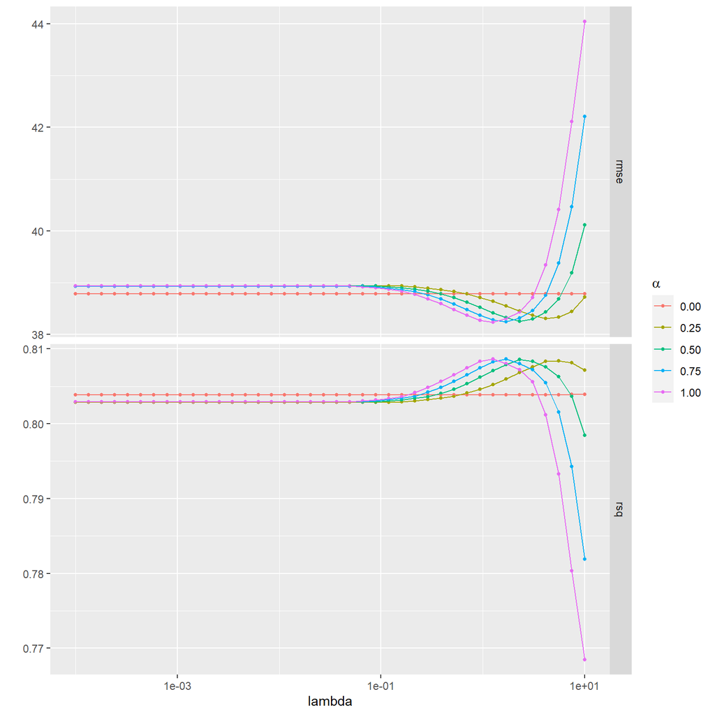

```r
mod_elastic %>% autoplot()
```

### Construcción Modelo Final

```r
elastic_net <-
  linear_reg(mixture = 0.25, penalty =7.443803) %>%
  set_mode("regression") %>% set_engine("glmnet")
wflow_elastic <-
  workflow() %>% add_recipe(rec_reg_elastic) %>% add_model(elastic_net)
mod_elastic_fit <-
  wflow_elastic %>% fit(train_data)
```

### Coeficientes Modelo FInal

Hagamos la representación del modelo resultante.

```r
tidy(mod_elastic_fit)
```

```
# A tibble: 54 × 3
   term         estimate penalty
   <chr>           <dbl>   <dbl>
 1 (Intercept)    417.      7.44
 2 MSSubClass       0       7.44
 3 LotFrontage      0       7.44
 4 LotArea          6.13    7.44
 5 YearBuilt       13.7     7.44
 6 YearRemodAdd    11.2     7.44
 7 TotalBsmtSF     11.2     7.44
 8 2ndFlrSF         2.75    7.44
 9 GrLivArea       27.1     7.44
10 GarageArea      11.8     7.44
# … with 44 more rows
```

### Predicción

Ahora realizaremos la evaluación y predicción en Test.

```r
# Predecimos en tst
fit_elastic <- mod_elastic_fit %>% last_fit(split = viviendas_split)
# Evaluamos en test
fit_elastic%>% collect_metrics()
```

```
# A tibble: 2 × 4
  .metric .estimator .estimate .config
  <chr>   <chr>          <dbl> <chr>
1 rmse    standard      29.2   Preprocessor1_Model1
2 rsq     standard       0.871 Preprocessor1_Model1
```

Vemos que las métricas son muy similares al set de validación, e incluso tenemos una reducción en el RMSE.

```r
# Errores en test
pred_test <-
  fit_elastic%>%
  collect_predictions() %>%
  mutate(error = SalePrice - .pred)
pred_test
```

```
# A tibble: 219 × 6
   id               .pred  .row SalePrice .config               error
   <chr>            <dbl> <int>     <dbl> <chr>                 <dbl>
 1 train/test split  424.     6      378. Preprocessor1_Model1 -46.2
 2 train/test split  373.     9      360. Preprocessor1_Model1 -12.7
 3 train/test split  345.    16      363. Preprocessor1_Model1  18.1
 4 train/test split  551.    21      570. Preprocessor1_Model1  19.1
 5 train/test split  448.    29      456. Preprocessor1_Model1   7.12
 6 train/test split  258.    30      262. Preprocessor1_Model1   4.03
 7 train/test split  543.    36      556. Preprocessor1_Model1  13.1
 8 train/test split  516.    46      566. Preprocessor1_Model1  49.5
 9 train/test split  347.    49      336. Preprocessor1_Model1 -10.7
10 train/test split  349.    50      356. Preprocessor1_Model1   7.42
# … with 209 more rows
```

Calculamos el error y graficamos la predicción con el valor real.

[figure not shown]

```r
# Gráficos en test
ggplot(data = pred_test,
       mapping = aes(x = .pred,
                     y = SalePrice)) +
  geom_point(color = "#006EA1",
             alpha = 0.6,
             size = 4) +
  # Diagonal
  geom_abline(intercept = 0, slope = 1,
              color = "orange", size = 1.2) +
  theme_economist() +
  labs(title = "Resultados regresión lineal saturada",
       subtitle =
         "Valores deberían estar cercanos a la diagonal",
       caption =
         "Autor: Roberto Bonilla| Datos: Ames Housing Dataset",
       x = "Predicciones",
       y = "Valores reales")
```

Podemos ver que los valores están cercanos a la diagonal y el error está con varianza controlada.

### Diagnosis de Regresión

Grafiquemos los residuales

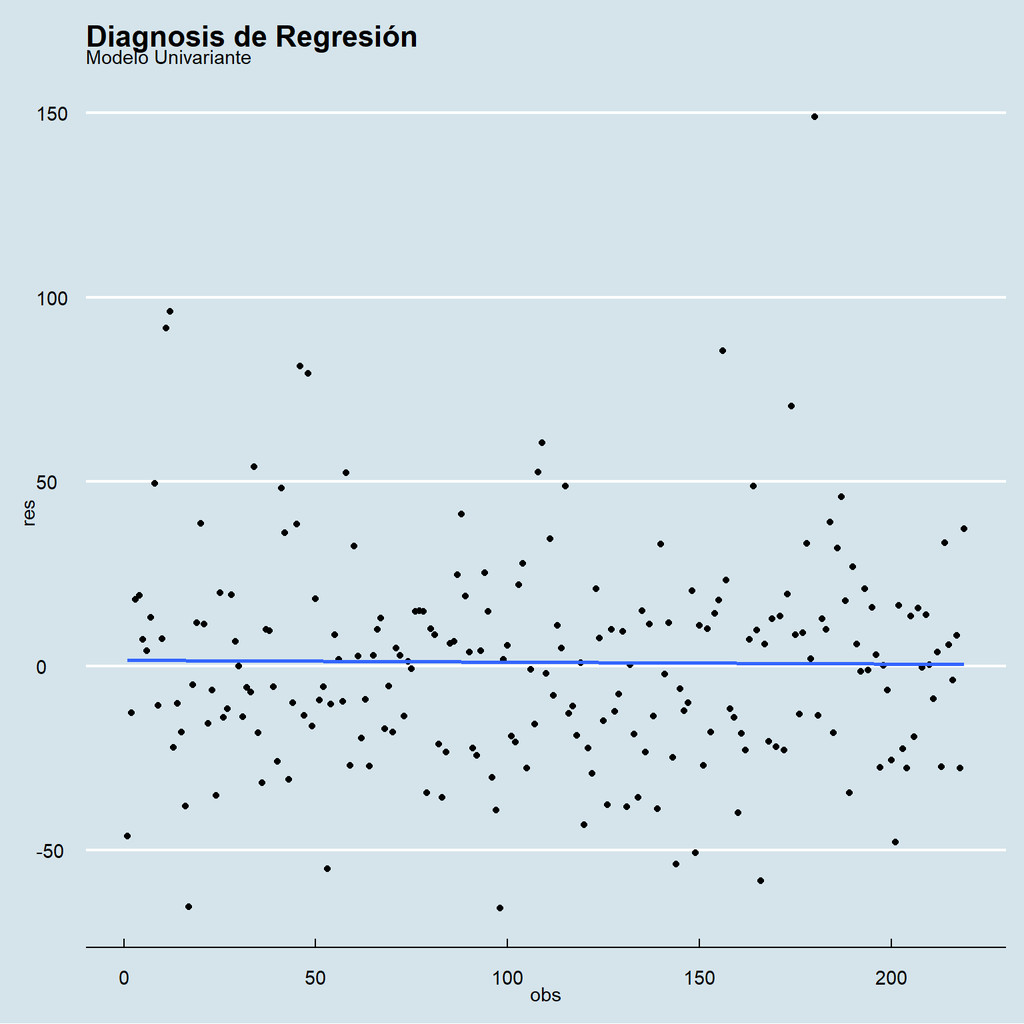

```r
ggplot(
  tibble("obs" = 1:length(pred_test$error),
         "res" = pred_test$error),
  aes(x = obs, y = res)) +
  geom_point() +
  geom_smooth(method = "lm", se = FALSE) +
  labs(title="Diagnosis de Regresión", subtitle="Modelo Univariante")+
  theme_economist()
```

Podemos ver que no existe una banda de error definida, sin embargo los residuos parecen seguir una recta en su tendencia (lo cual es adecuado).

#### Normalidad de los residuos

```r
ols_test_normality(pred_test$error)
```

```
-----------------------------------------------
       Test             Statistic       pvalue
-----------------------------------------------
Shapiro-Wilk              0.944          0.0000
Kolmogorov-Smirnov        0.0926         0.0467
Cramer-von Mises         17.6503         0.0000
Anderson-Darling          2.2634         0.0000
-----------------------------------------------
```